# Газар чөлөөлөлтийн системийн тайлан

[figure not shown]

**Нийслэлийн газар зохион**

**байгуулалтын алба**

**Ай Ти системс ХХК**

**ГАЗРЫН УДИРДЛАГЫН НЭГДСЭН МЭДЭЭЛЛИЙН СИСТЕМД СУУРИЛСАН ГАЗАР ЧӨЛӨӨЛӨЛТИЙН НЭГДСЭН СИСТЕМ**

**СИСТЕМ ХӨГЖҮҮЛЭЛТИЙН ТЕХНИКИЙН ТАЙЛАН**

Улаанбаатар хот

2026 он

## ТОВЧ ХУРААНГУЙ

Энэхүү систем нь газар чөлөөлөлтийн ажлыг цаасан бүртгэлээс газрын удирдлагын нэгдсэн цахим системд суурьлан бүрэн цахим хэлбэрт шилжүүлсэн нэгдсэн вэб систем юм. Газар чөлөөлөх төлөвлөгөө батлагдснаас эхлээд нөлөөлөлд өртсөн нэгж талбар бүрийг бүртгэх, хөрөнгийн үнэлгээ хийлгэх, нөхөх олговрыг тооцож батлах, эцэст нь газрыг чөлөөлөх хүртэлх бүх алхам нэг системд, хяналттай дарааллаар явагдана.

Ажлын алхам бүр тодорхой эрх бүхий хүнээр хийгддэг: Ахлах мэргэжлитэн чөлөөлөлтийн мэдээллийг бүртгэж тухайн чөлөөлөлтийн нөлөөлөлд өртсөн газруудын мэдээлэлтэй ажиллах мэргэжилтнүүдийг бүртгэнэ, үнэлгээний байгууллага үнэлгээгээ оруулж илгээнэ, санхүүгийн мэргэжилтэн баталгаажуулна. Аль нэг төлөв өөрчлөгдөх бүрт холбогдох хүмүүст мэдэгдэл шууд очиж, үйлдэл бүр хэн, хэзээ, хаанаас хийснээр нь бүртгэгдэж үлдэнэ (аудит лог). Газрын зураг дээр талбар бүрийн явц өнгөөр ялгарч бодит цагт харагдана.

Гол үзүүлэлтүүд: 327 үйлчилгээний цэг (API endpoint), 105 өгөгдлийн хүснэгт, 41 дэлгэц, 771 автомат тест. Газрын удирдлагын системтэй (ГУС) холболт хийгдэж, ашиглалтад орсноор нэгж талбарын эрх зүйн баталгаат эх сурвалж болох кадастр мэдээллийн систем, газар зохион байгуулалт, төлөвлөлтийн систем, газрын үнэлгээний систем, хот байгуулалтын кадастр, газрын мониторингийн системүүдээс өгөгдөл бодит холболтоор татагдаж байна. Түүнчлэн ХУР (XYP) гарцаар УБЕГ-ийн газар өмчлөл, E-Mongolia-гийн мэдэгдэл илгээх, системээс гадагш нөхөх олговрын мэдээг API ашиглан хүргэх боломжтой болсон ба бусад системүүдэд ашиглах боломжтой нээлттэй GIS давхарга нээгдсэн. 2026-09-09-өөс хойш 2010-2025 оны мэдээллийг нөхөж оруулах “Хуучин мэдээлэл оруулах” модуль (2.7.1) хийгдсэн нь газар чөлөөлөлтийн мэргэжилтнүүд хараат бус байдлаар өөрсдийн чөлөөлсөн газруудын мэдээллийг системд оруулан ажиллаж байна. Ажлын даалгаврын хөгжүүлэлтийн 50 ажил бүгд хийгдсэн буюу гүйцэтгэл 50/50 буюу 100% хөгжүүлэлтийг хийж дуусгасан. Үүнээс гадна ажлын даалгаварт тусгагдаагүй буулгалтын мэдээлэл, газрын судалгаа, он цагийн зураг, санхүүгийн самбар, трас зураг, төсөөллийн үнэлгээ зэрэг нэмэлт ажлууд хийгдсэн.

## 1. ЕРӨНХИЙ ТОЙМ

Систем нь дөрвөн үндсэн бүрэлдэхүүнээс тогтоно: хэрэглэгчийн харах вэб апп (Next.js 14), бизнесийн логикийг гүйцэтгэх бакенд сервер (Go/Gin REST API), өгөгдөл хадгалах сан PostgreSQL + газарзүйн PostGIS өргөтгөл болон орон зайн мэдээллийг зураглах сервер(GeoServer).

Гол тоон үзүүлэлтүүд:

| **Үзүүлэлт** | **Утга** |
| --- | --- |
| **REST API endpoint (үйлчилгээний цэг)** | 327 |
| **Өгөгдлийн сангийн хүснэгт (2 сан)** | 105 |
| **Хувилбарлагдсан migration (бүтцийн өөрчлөлт)** | 62 |
| **Frontend хуудас (route)** | 41 |
| **Нийт кодын мөр (Go + TS/TSX)** | ~141,600 |
| **Автомат тест функц (сервер 607 + вэб 164)** | 771 |

| **ҮР ДҮН** | **ДАВУУ ТАЛ** | **НЭМЭГДЭХ БОЛОМЖ** |
| --- | --- | --- |
| Газар чөлөөлөлтөөс нөхөх олговор хүртэлх бүх үе шат нэг системд цахимжсан бөгөөд 4 бүрэлдэхүүн бүрэн холбогдсон | Frontend/backend тусдаа тул багууд зэрэг хөгжүүлэх боломжтой, мөн GIS анхнаасаа гол хэсэг | Мобайл апп, ДАН нэвтрэлт (ХУР-ын холболт хийгдсэн) |

### 1.1 Хөгжүүлэлтийн явцын үзүүлэлт

Газар чөлөөлөлтийн мэдээллийн системийн хөгжүүлэлт 2026.06.19-өөс эхэлж, хоёр repository-д нийт 411 шинэчлэлт бүртгэгдсэн (frontend 247, backend 164).

Хөгжүүлэлтийн гол мөчлөгүүд:

- 2026.06.19-ны өдөр систем хөгжүүлэлтийн ажил эхэлсэн.
- 2026.07.20-нд систем 50% гүйцэтгэлийн явцын тайланг гэрээт хугацаанд хоцролгүй өгч чадсан. Бид систем хөгжүүлэлтийн гүйцэтгэлийн тайланг 67% гүйцэтгэлтэйгээр хийсэн бөгөөд тайланд тусган хүргүүлсэн.
- 2026.08.14-ны өдөр Ерөнхий газрын орон зайн хэлтэс ГУС-д хандах эрхийг нээж өгсөн бөгөөд ГУС-тэй холбогдож ажиллах хэсгүүдийн хөгжүүлэлтийг хийж гүйцэтгэсэн.
- 2026.09.18-ны өдөр бид гэрээт ажлыг 100% гүйцэтгэж дууссан мэдэгдлийг хүргүүлсэн боловч Нийслэлийн газрын албанд буй өмнөх оны чөлөөлөлтийн мэдээний хангалтгүй мэдээллийн асуудалтай тулгаран бид ахин хариуцсан хэлтсийн дата өгөгдлийг бүрэн болох хүртэл системээ туршиж үйл ажиллагааг жигдрүүлэх ажлыг хийж гүйцэтгэсэн.
- 2026.10.14-нд албаны дарга болон бусад холбогдох дарга нарт танилцуулга хийснээр 11-р сард багтаан өмнөх оны дата мэдээллийг хамтран оруулах чиглэл авсан. Газар чөлөөлөлтийн нийт 3-н хэлтэс өөрсдийн эрхээс системд нэвтрэн өөрт холбогдох газар чөлөөлөлтийн мэдээллүүдийг оруулж ажилласан.

Системд шинэчлэлт хөгжүүлэлт хийгдсэн байдал:

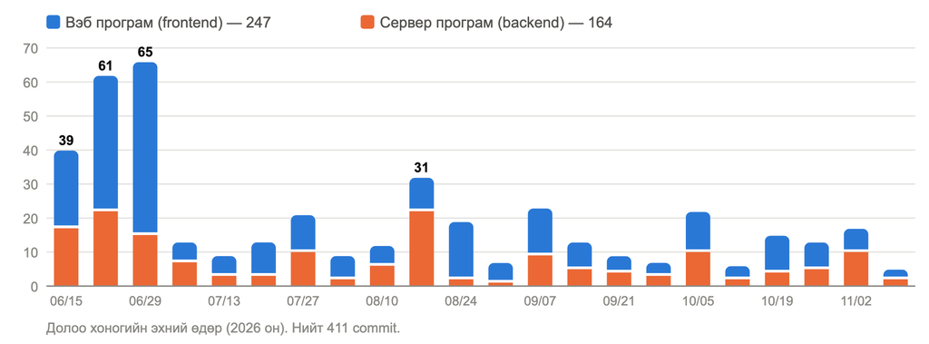

*Зураг 1. Хөгжүүлэлтийн явц: долоо хоног тус бүрийн commit-ийн тоо (вэб ба сервер програм)*

### 1.2 Ажлын даалгаврын биелэлтийн товч

Ажлын даалгаврын (төлөвлөгөөний) 1 ба 2-р бүлгийн **хөгжүүлэлтийн 50 ажил бүгд хийгдсэн**. Ажил тус бүрийн хэрэгжилтийг 10-р бүлэгт ажлын даалгаварт бичигдсэн нэрээр нь харуулав.

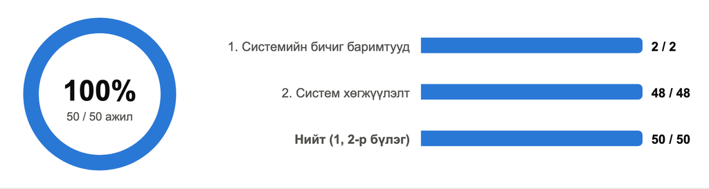

*Зураг 2. Ажлын даалгаврын хөгжүүлэлтийн гүйцэтгэл: 50 ажлаас 50 нь хийгдсэн*

| **Бүлэг** | **Ажлын тоо** |
| --- | --- |
| 1. Системийн бичиг баримтууд | 2 |
| 2. Систем хөгжүүлэлт | 48 |
| **Нийт** | **50** |

Ажлын даалгаварт байхгүй боловч хийгдсэн ажлуудыг 10.3-т “Нэмэлт ажлууд” гэж тайлагнав.

### 1.3 API интерфейс, эндпойны товч

Backend нь /api/v1 суурьтай 327 REST endpoint ашиглан фронтенд болон бусад системүүдтэй холбогдож ажилладаг.

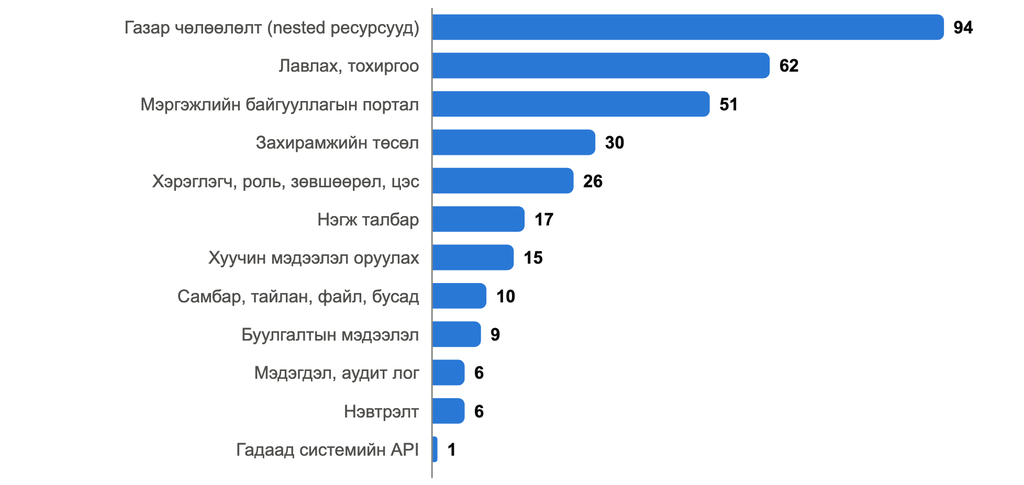

*Зураг 3. Бүлэг тус бүрийн API endpoint-ийн тоо (нийт 327)*

| № | **Бүлэг** | **API тоо** |
| --- | --- | --- |
| 1 | **Газар чөлөөлөлт (nested ресурсууд)** | 94 |
| 2 | **Лавлах, тохиргоо (15 бүлэг)** | 62 |
| 3 | **Мэргэжлийн байгууллагын портал (/prof)** | 51 |
| 4 | **Захирамжийн төсөл (төсөл хянах нэгж орсон)** | 30 |
| 5 | **Хэрэглэгч, роль, зөвшөөрөл, цэс** | 26 |
| 6 | **Нэгж талбар (global, газрын судалгаа орсон)** | 17 |
| 7 | **Хуучин мэдээлэл оруулах (/legacy-import)** | 15 |
| 8 | **Буулгалтын мэдээлэл (/land-releases)** | 9 |
| 9 | **Самбар, тайлан, файл, бусад (санхүүгийн самбар, он цагийн зураг орсон)** | 10 |
| 10 | **Мэдэгдэл, аудит лог** | 6 |
| 11 | **Нэвтрэлт (мэргэжлийн байгууллагын нэвтрэлт орсон)** | 6 |
| 12 | **Гадаад системийн API (/external, API key)** | 1 |
|  | **Нийт** | **327** |

### 1.4 Мэдээллийн сангийн хүснэгтийн задаргааны товч

Өгөгдлийн сангийн 105 хүснэгт домэйнд хуваагдана. Main DB-д байх 86 хүснэгт нь газар чөлөөлөлт болон түүнтэй холбоотой мэдээллийг хадгалах үүрэгтэй, харин auth DB-д 19 хүснэгт байх ба эдгээр нь хэрэглэгчийн мэдээлэл болон хандах эрхийн зохицуулалтуудыг хадгалах үүрэгтэй.

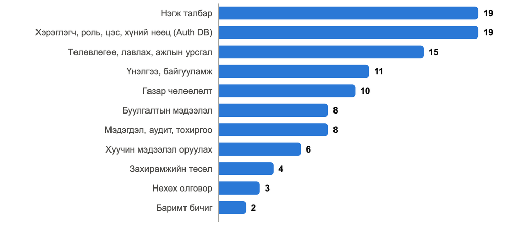

*Зураг 4. Домэйн тус бүрийн өгөгдлийн сангийн хүснэгтийн тоо (нийт 105)*

| **№** | Бүлэг | **Хүснэгт** |
| --- | --- | --- |
| 1 | Нэгж талбар (эзэмшигч, өмчлөл, төлбөр, барьцаа, мониторинг, мэдэгдэл, давхцал, судалгаа) | 19 |
| 2 | Төлөвлөгөө, лавлах, ажлын урсгал | 15 |
| 3 | Үнэлгээ, байгууламж, үнэлгээний байгууллага | 11 |
| 4 | Газар чөлөөлөлт (хил, явц, ажилтан, санхүүжилт, дрон, НЭЗ судалгаа) | 10 |
| 5 | Буулгалтын мэдээлэл | 8 |
| 6 | Мэдэгдэл, аудит лог, системийн бүртгэл, тохиргоо | 8 |
| 7 | Хуучин мэдээлэл оруулах (түр хадгалах схем) | 6 |
| 8 | Захирамжийн төсөл | 4 |
| 9 | Нөхөх олговор | 3 |
| 10 | Баримт бичиг | 2 |
| 11 | **Main DB нийт** | **86** |
| 12 | Хэрэглэгч, роль, зөвшөөрөл (Auth DB) | 7 |
| 13 | Цэс, форм, эрхийн холбоос (Auth DB) | 5 |
| 14 | Байгууллага, хүний нөөц, иргэн (Auth DB) | 5 |
| 15 | Кодын лавлах (Auth DB) | 2 |
|  | **Auth DB нийт** | **19** |
|  | **Нийт** | **105** |

## 2. СИСТЕМИЙН АРХИТЕКТУР

Backend нь Clean Architecture зарчмаар давхаргажсан (handler, service, repository, PostgreSQL гэсэн дарааллаар), харин frontend нь Next.js App Router бүтэцтэй.

| **Давхарга** | **Тайлбар** |
| --- | --- |
| **Вэб апп: Next.js 14** | 41 хуудас, GeoServer прокси, SSE Excel тайлан, DOCX загвар, React Query, OpenLayers, CesiumJS 3D |
| **REST API: Go 1.25 / Gin** | Handler (58), Service (68), Repository (56, raw SQL/pgx) гэсэн дарааллаар. Middleware: JWT, RBAC, assignment, lock, rate-limit. Swagger |
| **Main DB: PostgreSQL 16 + PostGIS 3.4** | Бизнес өгөгдөл: 86 хүснэгт, геометр (EPSG:4326), ST_* орон зайн тооцоолол, UTM талбайн функц |
| **Auth DB: PostgreSQL 16** | Хэрэглэгч, роль, зөвшөөрөл, цэс, хүний нөөц: 19 хүснэгт, тусдаа сан |
| **GeoServer 2.25: WMS/WFS** | Захиргааны нэгж, төлөвлөгөө, талбарын статусын давхаргууд, нээлттэй `v_parcel_public` давхарга, CQL шүүлт |

Кодын хэмжээ: Backend (Go, тестгүй) 66,072 мөр, Frontend (TS/TSX) 75,572 мөр.

## 3. ТЕХНОЛОГИЙН СТЕК

| **Хэсэг** | **Технологи** | **Үүрэг** |
| --- | --- | --- |
| **Frontend** | Next.js 14.2, React 18, TypeScript 5 | App Router, SSR/standalone build |
|  | Radix UI + Tailwind CSS 3.4 | Хүртээмжтэй UI, dark mode |
|  | TanStack React Query 5 | Сервер өгөгдлийн кэш |
|  | react-hook-form + zod | Маягт, схем валидаци |
|  | OpenLayers 10.2 | Газрын зургийн дүрслэл |
|  | exceljs, SheetJS, pdf-lib, recharts | Excel, PDF, график |
| **Backend** | Go 1.25, Gin 1.10 | HTTP framework, middleware |
|  | pgx/v5 + pgxpool | ORM-гүй raw SQL |
|  | golang-jwt/v5, bcrypt | Token, нууц үгийн хэшлэлт |
|  | golang-migrate/v4 | Автомат migration |
|  | swaggo/swag | Swagger баримтжуулалт |
| **Дэд бүтэц** | PostgreSQL 16 + PostGIS 3.4 | Реляцийн болон орон зайн сан (2 instance) |
|  | GeoServer 2.25, Docker, systemd | WMS/WFS, контейнержуулалт |

### 3.1 PHP-Laravel хэв маягтай харьцуулсан хурд

Төрийн байгууллагын вэб системүүдэд түгээмэл хэрэглэгддэг PHP-Laravel хэв маяг нь дэлгэц, бизнесийн логик, газрын зураг, өгөгдлийн санг нэг програм дотор нэгтгэдэг бөгөөд нэг хүсэлтийн доторх ажлуудаа дараалан гүйцэтгэдэг. Газар чөлөөлөлтийн системийн сервер програм Go хэл дээр бичигдсэн бөгөөд бие даасан асуулгуудыг зэрэг явуулж, нэг удаа ачаалагдаад санах ойд ажиллаж байдаг. Хяналтын самбар нээхэд өгөгдлийн сангаас найман өөр мэдээлэл асуух шаардлагатай байдаг тул энэ ялгаа хурдад шууд нөлөөлнө.

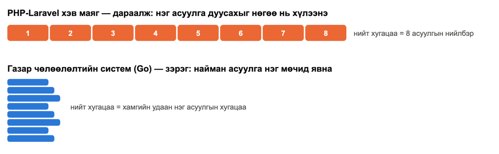

*Зураг 5. Найман асуулгыг дараалан ба зэрэг явуулах зарчим*

| **Хурдад нөлөөлөх зүйл** | **PHP-Laravel хэв маяг** | **Газар чөлөөлөлтийн систем (Go)** |
| --- | --- | --- |
| **Нэг хүсэлтийн доторх ажил** | Дараалж явна, нэг нь дуустал нөгөө нь хүлээнэ | Зэрэг явна, бие даасан асуулгууд нэг мөчид |
| **Найман асуулгатай дэлгэц** | Найман асуулгын хугацаа нийлбэр болно | Хамгийн удаан нэг асуулгын хугацаа л зарцуулагдана |
| **Програм ачаалагдах** | Хүсэлт бүрт програм дахин ачаалагдана | Нэг удаа ачаалагдаад санах ойд ажиллана |
| **Олон хэрэглэгч зэрэг** | Хэрэглэгч бүрт тусдаа процесс тул санах ой хурдан дүүрнэ | Нэг програм мянга мянган хүсэлтэд зэрэг үйлчилнэ |
| **Хүнд тооцоо давтагдахад** | Ижил тооцоо дэлгэцийн хэсэг бүрт дахин хийгдэнэ | Нэг удаа бодоод бүх хэсэгт дамжуулна |
| **Хэмжих, шалгах** | Хурдыг тогтмол хэмжих бэлэн арга байхгүй | Хэмжилт автоматжсан тул өөрчлөлт хурдыг муутгавал шууд илэрнэ |

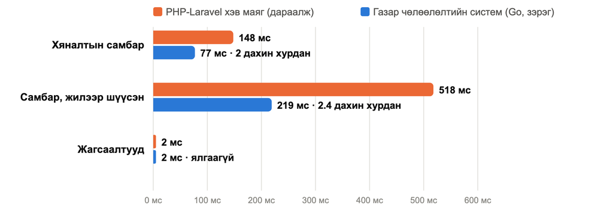

*Зураг 6. Ижил дэлгэцийн хариу өгөх хугацаа: PHP-Laravel хэв маягаар (дараалж) ба Газар чөлөөлөлтийн системээр (зэрэг)*

**Хэмжилтийн арга.** Ижил систем, ижил асуулга, ижил өгөгдөл дээр зөвхөн зэрэгцээ ажиллагааг салгаж хэмжсэн: PHP-Laravel хэв маягийн утга нь асуулгуудыг дараалуулан явуулсан (PHP-FPM нэг хүсэлт дотроо ажлаа дараалуулдагтай ижил) нөхцөл юм. Тус бүрийг 12 удаа хэмжиж медиан утгыг авсан. Туршилтын сан: 100 чөлөөлөлт, 10 000 нэгж талбар, 30 000 олговор, 50 000 төлөвийн түүх.

Жагсаалт нэг л асуулга явуулдаг тул дараалуулах зүйлгүй бөгөөд хоёр аргын хооронд зөрүү гарахгүй. Харин найман асуулгатай хяналтын самбар 2-2.4 дахин хурдан ажиллана. Бодит PHP-Laravel систем дээр үүн дээр нэмээд хүсэлт бүрийн програм ачаалалт, ORM-ийн мөр боловсруулалт нэмэгддэг тул бодит зөрүү үүнээс их байна.

## 4. МЭДЭЭЛЛИЙН САНГИЙН БҮТЭЦ

Өгөгдөл хоёр тусдаа санд хуваагдана: бизнес өгөгдлийн main DB (86 хүснэгт, PostGIS өргөтгөлтэй) ба хэрэглэгч/эрх/хүний нөөцийн auth DB (19 хүснэгт). Хоёр санг тусгаарласнаар хэрэглэгчийн нууц мэдээлэл бизнес өгөгдлөөс салангид хамгаалагдаж, тус тусдаа нөөцлөх/сэргээх боломжтой. Schema-ийн өөрчлөлт бүр migration-аар (up/down хостой) бүртгэгдэж, сервер асахад автоматаар хэрэгжинэ. Нэгтгэсэн baseline-аас хойш нийт 62 migration байна.

### 4.1 Бүтцийн ерөнхий диаграм (ERD)

[figure not shown]

*Зураг 7. Өгөгдлийн сангийн хялбаршуулсан ERD: хоёр сан, гол хүснэгтүүд ба харилцаанууд*

### 4.2 Гол хүснэгтүүдийн дэлгэрэнгүй

Домэйн бүрийн төв хүснэгтүүд, тэдгээрийн гол баганууд (DB-ээс шууд гаргав):

[output not shown]

### 4.3 Домэйн тус бүрийн хүснэгтийн бүрэн задаргаа

[output not shown]

### 4.4 Гол харилцаанууд ба онцлох дизайны шийдлүүд

- **Сан хоорондын холбоос:** ГУС-ээс системд байнга холбогдож ажиллах хэсэг нь хэрэглэгчийн нэвтрэлтийн хэсэг юм. Бусад үйлдлүүд нэг л удаа хийгдэх бөгөөд чөлөөлөлтийн систем мэдээллийг өөр дээрээ хадгалснаар ГУС-т ачаалал үүсгэхгүй, хамааралгүй ажиллана.
- **Гол гинжин холбоо:** Газар чөлөөлөлт (land_acquisition) нь олон нэгж талбартай (parcel) холбогдож ажиллах боломжтой. Нэгж талбар тус бүр 3 өөр үнэлгээний мэдээлэлтэй холбогдох боломжтой бөгөөд эдгээр нь үндсэн, хөндлөнгийн, мика гэсэн үнэлгээний байгууллагуудын үнэлгээний мэдээлэл юм.
- **Орон зайн багана:** geometry(Polygon, 4326) баганын тусламжтайгаар давхцлын талбайг DB дотор ST_Intersection, ST_Area-гаар автоматаар тооцно.
- **Түүхжүүлэлт (аудит):** статус (parcel_status_history, acquisition_progress), хил (boundary_history), олговор (compensation_history), үнэлгээ (submission_history) зэргийн өөрчлөлт бүр хэн, хэзээ, юу хийсэн гэдгээр архивлагдана.
- **RBAC бүтэц:** users, user_roles, roles, role_permissions, permissions гэсэн дарааллаар холбогдоно. Хандах эрхийг resource:action хэлбэрийн зөвшөөрлөөр шалгана.
- **Хамгаалалт:** Excel импорт source_file_hash (SHA-256)-аар давхардлаас сэргийлнэ. Мөн revoked_tokens ба tokens_valid_from нь token-ийн давхар хамгаалалт болно.

## 5. API ИНТЕРФЕЙС: 327 ENDPOINT

Backend нь /api/v1 суурьтай 327 REST endpoint (програмуудын хооронд мэдээлэл солилцох үйлчилгээний цэг) үзүүлдэг, бүгд Swagger-ээр баримтжсан. Эдгээрээс 326 нь JWT-ээр нэвтэрсэн хэрэглэгчид, 1 нь гадаад системд API key ашиглан хандахад зориулагдсан.

| **Бүлэг** | **Endpoint** |
| --- | --- |
| **Газар чөлөөлөлт (nested ресурсууд)** | 94 |
| **Лавлах, тохиргоо (15 бүлэг)** | 62 |
| **Мэргэжлийн байгууллагын портал (/prof)** | 51 |
| **Захирамжийн төсөл (төсөл хянах нэгж орсон)** | 30 |
| **Хэрэглэгч, роль, зөвшөөрөл, цэс** | 26 |
| **Нэгж талбар (global, газрын судалгаа орсон)** | 17 |
| **Хуучин мэдээлэл оруулах (/legacy-import)** | 15 |
| **Буулгалтын мэдээлэл (/land-releases)** | 9 |
| **Самбар, тайлан, файл, бусад (санхүүгийн самбар, он цагийн зураг орсон)** | 10 |
| **Мэдэгдэл, аудит лог** | 6 |
| **Нэвтрэлт (мэргэжлийн байгууллагын нэвтрэлт орсон)** | 6 |
| **Гадаад системийн API (/external, API key)** | 1 |
| **Нийт** | **327** |

- **SSE стрийм:** Excel тайланг Server-Sent Events-ээр явцын мэдээлэлтэй, хамгийн сүүлийн байдлаар татдаг.
- **Прокси:** GeoServer reverse proxy ашигладаг тул GIS дэд бүтэц гадагш ил гардаггүй.
- **Алдааны нэгдсэн урсгал:** 401 үед token сэргээгдэнэ, 403 үед эрхийн мэдэгдэл, 5xx үед алдааны хуудас гарна.
- **Гадаад системд өгөгдөл гаргах гарц:** `GET /api/v1/external/compensations` нь нөхөх олговрын үндсэн (тайлангийн) үнэлгээний мэдээллийг гадаад системд гаргана. Танилт нь `X-API-Key` (эсвэл Bearer) бөгөөд түлхүүрүүд SHA-256 хэшээр тулгагдаж, тогтмол хугацааны (constant-time) харьцуулалт хийгдэнэ. Түлхүүр тохируулаагүй бол үйлчилгээ бүхэлдээ хаалттай (503, deny-by-default), хүсэлтийн хязгаар 120/мин.
- **Гадаад систем рүү хүсэлт илгээх:** бусад (гадаад) систем рүү HTTP хүсэлт илгээх нэгдсэн `httpclient` багц. Үүгээр дамжсан дуудлага бүр (method, host, замын зам, хүсэлт/хариу, төлөв, хугацаа) `client_request` хүснэгтэд автоматаар бүртгэгдэж, admin-only `GET /client-requests`-ээр харагдана. ГУС-ийн холболт энэ багцаар дамжин ажиллаж байгаа тул кадастр, ГЗБ, үнэлгээ, мониторингийн дэд систем рүү явсан дуудлага бүр түүх болж хадгалагдах боломжтой.

## 6. АЮУЛГҮЙ БАЙДАЛ, ЭРХИЙН УДИРДЛАГА

### 6.1 Нэвтрэлт (Authentication)

- JWT (HS256): access 24 цаг ба refresh 7 хоног (.env тохиргоогоор), тусдаа нууц түлхүүртэй.
- Нууц үг bcrypt хэшээр, сэргээх token SHA-256, 1 цагийн TTL-тэй.
- Гарахад token хүчингүйжүүлэлт + нууц үг солиход бүх session таслагдана (epoch)

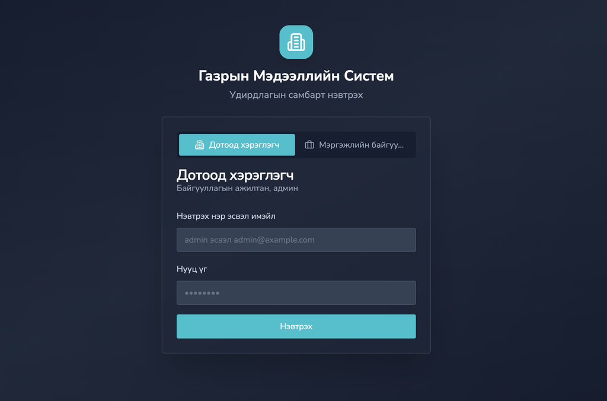

*Зураг 8. Системд нэвтрэх дэлгэц*

### 6.2 Ролиуд ба зөвшөөрөл

| **Роль** | **Хамрах хүрээ** |
| --- | --- |
| **admin: Системийн администратор** | Бүх зөвшөөрөл, тохиргоо, хүний нөөц, хуучин мэдээлэл оруулах, мэдэгдэх хуудас илгээх. Системд 3-аас ихгүй |
| **department_head: Хэлтсийн дарга** | Өөрийн хэлтсийн чөлөөлөлт, нэгж талбар, ажилтны ажлыг хянах |
| **senior_specialist: Ахлах мэргэжилтэн** | Чөлөөлөлт үүсгэх/засах, ажилтан хуваарилах, батлах үйлдлүүд, тайлан, хэрэглэгч харах |
| **employee: Мэргэжилтэн** | Өөрт хуваарилагдсан, өөрийн хэлтсийн чөлөөлөлт дээр ажиллах |
| **decision_registration: Захирамж бүртгэл** | Захирамжийн төсөл бэлтгэх, явц бүртгэх, шийдвэр баталгаажуулах |
| **professional_org: Мэргэжлийн байгууллага** | Зөвхөн /prof портал, өөрт оноогдсон нэгж талбарын үнэлгээг оруулна |
| **mika: МИКА** | Зөвхөн /prof портал, өөрт оноогдсон нэгж талбарын үнэлгээг оруулна |
| **finance_specialist: Санхүү** | Нөхөх олговрын хяналт, баталгаажуулалт, санхүүгийн самбар |

Зөвшөөрөл resource:action хэлбэртэй, JWT дотор шингэсэн тул шалгалт DB хандалтгүй. Middleware 4 түвшний хамгаалалт давхарлана: permission/role шалгалт, хуваарилалтын шалгалт, түгжээний шалгалт, байгууллагын гишүүнчлэл.

### 6.3 Роль тус бүрийн цэсийн хандалт

Тэмдэглэгээ: ✓ бүрэн хандана, ◐ нөхцөлтэй буюу хязгаартай хандана, — тухайн цэс харагдахгүй.

| **Цэс / Үйлдэл** | **Админ** | **Ахлах** | **Мэргэжилтэн** | **Мэрг.байг.** | **МИКА** | **Санхүү** |
| --- | --- | --- | --- | --- | --- | --- |
| **Хяналтын самбар** | **✓** | **✓** | **✓** | **◐¹** | **◐¹** | **◐¹** |
| **Газар чөлөөлөлт** | **✓** | **✓** | **◐⁷** | **◐²** | **◐³** | **◐³** |
| **Тайлан** | **✓** | **✓** | — | — | — | — |
| **Газрын зураг** | **✓** | **✓** | **✓** | — | — | — |
| **Нэгж талбар** | **✓** | **✓** | **◐⁷** | — | — | **◐³** |
| **Газрын судалгаа** | **✓** | **✓** | **◐⁷** | — | — | — |
| **Буулгалтын мэдээлэл** | **✓** | **✓** | **◐⁷** | — | — | — |
| **Захирамж (төсөл, шийдвэр)** | **✓** | **◐⁶** | **◐⁶** | — | — | — |
| **Хуучин мэдээлэл оруулах** | **✓** | — | — | — | — | — |
| **“Удирдлага” цэсийн “Хэрэглэгчид”** | **✓** | **◐⁴** | — | — | — | — |
| **“Удирдлага” цэсийн “Эрх & Роль”, “Үйлдлийн лог”, “Хүний нөөц”** | **✓** | — | — | — | — | — |
| **Тохиргоо (10 модуль)** | **✓⁵** | — | — | — | — | — |

¹ Самбарын цар хүрээ ролиор хязгаарлагдана. ² Зөвхөн өөрт оноогдсон (/my_acquisitions). ³ Дэлгэрэнгүйд зөвхөн “Ерөнхий”, “Нэгж талбар” таб. ⁴ users:read, зөвхөн харах. ⁵ admin:read эрхтэйд харагдана. ⁶ `decision:read` зөвшөөрөлтэй үед (Захирамж бүртгэл рольд бүрэн). ⁷ Өөрийн хэлтсийн, өөрт хуваарилагдсан чөлөөлөлтийн хүрээнд.

### 6.4 Мэдээлэлтэй ажиллах эрхийн матриц

| **Цэс / Үйлдэл** | **Админ** | **Ахлах** | **Мэргэжилтэн** | **Мэрг.байг.** | **МИКА** | **Санхүү** |
| --- | --- | --- | --- | --- | --- | --- |
| **Газар чөлөөлөлт** |  |  |  |  |  |  |
| **Жагсаалт, дэлгэрэнгүй харах** | **✓** | **✓** | **◐ᵃ** | **◐ᵇ** | **✓** | **✓** |
| **Үүсгэх, засах** | **✓** | **✓** | — | — | — | — |
| **Устгах** | **✓** | — | — | — | — | — |
| **Статусын workflow шилжүүлэх** | **✓** | **✓** | — | — | — | — |
| **Нэгж талбар** |  |  |  |  |  |  |
| **Талбарын мэдээлэл харах** | **✓** | **✓** | **◐ᵃ** | **◐ᶜ** | **◐ᶜ** | **◐ᶜ** |
| **Засах, баримт, төлбөр бүртгэх** | **✓** | **✓** | — | — | — | — |
| **Үнэлгээ (3 урсгал)** |  |  |  |  |  |  |
| **Үнэлгээний мэдээлэл харах** | **✓** | **✓** | **✓** | **◐ᵈ** | **✓** | **✓** |
| **Хөрөнгийн үнэлгээ оруулах** | — | — | — | **◐ᵉ** | — | — |
| **Хөндлөнгийн үнэлгээ оруулах** | — | — | — | **◐ᶠ** | — | — |
| **МИКА үнэлгээ оруулах** | — | — | — | — | **✓** | — |
| **Excel-ээс үнэлгээ импортлох** | **✓** | **✓** | — | **◐ᵉ** | **✓** | — |
| **Үнэлгээ илгээх (submit)** | — | **✓** | — | **◐ᵉ** | **◐ᵍ** | — |
| **Үнэлгээ батлах / буцаах** | — | — | — | — | — | **✓** |
| **Нөхөх олговор** |  |  |  |  |  |  |
| **Олговрын мэдээлэл харах** | **✓** | **✓** | **◐ᵃ** | **◐ᵇ** | **✓** | **✓** |
| **Олговор бүртгэх, засах** | **✓** | **✓** | — | **◐ᵉ** | **✓** | — |
| **Олговор батлах / татгалзах** | — | — | — | — | — | **✓ʰ** |
| **Удирдлага, тайлан** |  |  |  |  |  |  |
| **Хэрэглэгч удирдах (CRUD)** | **✓** | **◐ⁱ** | — | — | — | — |
| **Роль, зөвшөөрөл, тохиргоо** | **✓** | — | — | — | — | — |
| **Excel тайлан татах** | **✓** | **✓** | **✓** | — | — | — |

ᵃ Өөрт хуваарилагдсан чөлөөлөлт. ᵇ Өөрийн байгууллагад оноогдсон объект (/prof). ᶜ “Үнэлгээ хийх” статустай үед, хязгаартай табууд. ᵈ Зөвхөн өөрийн урсгал. ᵉ Үндсэн гүйцэтгэгчээр оноогдсон үед. ᶠ Хөндлөнгийн байгууллагаар оноогдсон талбарт. ᵍ МИКА өөрийн урсгалдаа. ʰ Зөвхөн санхүүгийн роль, админ ч эрхгүй. ⁱ users:read, зөвхөн харах.

## 7. GIS: ГАЗАРЗҮЙН МЭДЭЭЛЛИЙН ИНТЕГРАЦИ

[output not shown]

### 7.1 Суурь зургийг дэлгэцээс тохируулах (2.6.1)

Газрын зургийн суурь (агаар, сансрын) зургийн хаягийг админ дэлгэцээс гараар тохируулна. Мэдээлэл оруулаагүй бол системийн үндсэн суурь зураг хэвээр харагдана. Тохиргоо нь `app_setting` хүснэгтэд (`basemap` түлхүүр, JSONB) нэг мөрөөр хадгалагдах системийн хэмжээний тохиргоог админ (`admin:update`) эрхтэй хэрэглэгч л өөрчилнө, өөрчилмөгц бүх хэрэглэгчид ижил суурь зурагтай болно.

- **Зөвхөн хаяг авна:** хэрэглэгч нэг л зүйл буюу URL бөглөнө. Бусад параметрийг систем өөрөө тодорхойлно.
- **Төрлийг автоматаар таньдаг:** `{x}/{y}/{z}` хэлбэртэй бол **tile (XYZ)**, `service=WMS`, `/wms`, `/ows`, `/service`, `/mapserv` шинжтэй бол **WMS (растер)**, бусад тохиолдолд нэг зураг (**image**) гэж үзнэ.
- **WMS давхарга санал болгох:** хаяг оруулмагц сервер тал `GetCapabilities`-ийг уншиж (хөтчийн CORS-гүйгээр, `/api/basemap/probe`) давхаргын жагсаалтыг гаргаж, эхнийхийг автоматаар сонгоно.
- **Хамгаалалт:** зөвхөн `http(s)` хаягийг зөвшөөрнө. XYZ-д `{x}`,`{y}`/`{-y}`,`{z}` байх шаардлагатай, WMS-д давхарга, image-д 4 утгатай extent шаардана. Хамааралгүй талбарууд хадгалахын өмнө хасагдана.
- **Хаана байрлана:** газрын зургийн давхаргын самбарын доод хэсэгт “Суурь зураг” бүлэг, засах (⚙) товч байрлана.

### 7.2 Нээлттэй давхарга: гадны системд (2.9.2)

Чөлөөлөлтөд өртсөн бүх нэгж талбарыг явцын өнгө, нэртэйгээр харуулах `land:v_parcel_public` давхарга нээгдсэн. GeoServer өөрөө `127.0.0.1`-д хаалттай тул хандалт нь `/api/public/geoserver/*` гарцаар явна, нэвтрэлт, эрх шалгахгүй.

[output not shown]

Баримт: `docs/public-map-layer.md`. Давхарга, view, style нь GeoServer-ийн тохиргоонд (`make config`) идемпотентээр бүртгэгдэнэ.

## 8. ЧАНАР, ТЕСТИЙН ХАМРАЛТ

| **Үзүүлэлт** | **Утга** |
| --- | --- |
| **Нийт тест функц** | 771 |
| **Backend тест функц / файл** | 607 / 105 (өгөгдлийн сантай ажиллах e2e тест 63 функц орсон) |
| **Frontend тест функц / сьют** | 164 / 21 |
| **Mock багц (handler / service / repo)** | 3 |

Frontend-ийн тест нь өмнө нь эрхийн бодлого (access-policy), Excel үнэлгээний задлан шинжилгээ (valuation-parser) ба тооцоолол (valuation-calc), газрын зургийн давхарга (map-layers), ГЧХ-2 тайлан (gchh2-report), захирамжийн DOCX (decision-draft-docx), дараалсан гүйцэтгэгч (sequential-runner), ачааллын төлөв (blocking-loader-state)-ийг хамардаг байсан бол 2026-09-09-өөс хойш он цагийн зураг (chronos, timeline-months), төсөөллийн үнэлгээ (estimated-valuation), газрын зургийн бичээс байрлуулах (label-placement), хуучин мэдээлэл оруулах (legacy-import), хуудасны таб (page-tabs), төлбөрийн гүйцэтгэл (payment-performance), PDF зураг (pdf-images), Enter-ээр хайх (search-on-enter), нэвтрэлтийн хугацаа (session-token-expiry), төлөвийн өнгө ба нэр (status-colors, status-label), трас зураг (trace-print) гэсэн 13 сьют нэмэгдэж, нийт 21 болсон.

- **Давхаргажсан unit тест:** mock-оор тусгаарлагдсан, DB-гүйгээр хурдан ажиллана.
- **Хандалтын эрхийн тест:** router_access_test.go кодыг ашиглан хандах эрхийн кодод асуудал гарсан бол автоматаар илрүүлнэ.
- **Баримтжуулалт:** Swagger UI, Postman collection, монгол хэлний i18n
- **Гадаад холболтын тест:** ХУР (XYP) гарцын хариултын задаргаа, мэдэгдэх хуудасны имэйл, E-Mongolia, суурь зургийн валидаци, API key-ийн танилт (тохируулаагүй бол 503), олговрын гадаад API-ийн 3 хэлбэрийн шүүлтүүд. Шинээр 31 тест функц нэмэгдсэн.

## 9. ЦЭС, ДЭЛГЭЦҮҮДИЙН ДЭЛГЭРЭНГҮЙ ТАЙЛБАР

Энэ бүлэгт системийн цэс бүрийн зорилго, дэлгэц дээр харагдах мэдээлэл, хэрэглэгчийн гүйцэтгэх үйлдэл, шүүлтүүр болон эрхийн хязгаарлалтыг эх кодоос шууд гаргаж тайлбарлав. Чөлөөлөлт ба нэгж талбарын дэлгэрэнгүй хуудасны таб бүрийг тусад нь зурагтай нь тайлбарласан.

### 9.0 Дэлгэцүүдийн нэгдсэн хүснэгт

Систем нийт **41 дэлгэцтэй**: үндсэн үйл ажиллагааны 19, тохиргоо/лавлахын 10, хүний нөөцийн 6, хэрэглэгч-эрхийн болон системийн 6. Доорх хүснэгтэд дэлгэц бүрийн зам, гол үйлдэл, хийгдсэн байдлыг нэгтгэв.

| **№** | **Дэлгэц** | **Зам** | **Гол үйлдлүүд** |
| --- | --- | --- | --- |
| **А. Үндсэн үйл ажиллагаа (19)** |  |  |  |
| 1 | Хяналтын самбар (дотоод) | / | 6 шүүлтүүр, 4 KPI, статусын задаргаа, газрын зураг (2D/3D, он цагийн зураг, бүтэн дэлгэцийн хураангуй самбар), ГЧХ-2 мэдээ татах |
| 2 | Хяналтын самбар (гадаад роль, санхүү) | / | Үнэлгээний ажлын дараалал, төлөвийн график, олговрын дүн, мөн санхүүгийн мэргэжилтэнд мөнгөн дүнгийн тусдаа самбар |
| 3 | Газар чөлөөлөлтийн жагсаалт | /acquisition | 7 шүүлтүүр, он, баганаар эрэмбэлэх, 2 алхамт бүртгэл, устгах, дэлгэрэнгүй |
| 4 | Чөлөөлөлтийн дэлгэрэнгүй (8 таб) | /acquisition/[id] | Ерөнхий (+ НИТХ-ын тогтоол, НЭЗ судалгаа, хил солих), Хавсралт, Нэгж талбарууд, Санхүүжилт, Явц, Ажилтнууд, Байршил (ажлын зураг хэвлэх, дрон), Газрын судалгаа + тайлан татах |
| 5 | Миний чөлөөлөлтүүд | /my_acquisitions | Мэргэжлийн байгууллагад оногдсон ажлын жагсаалт |
| 6 | Нэгж талбарын жагсаалт | /parcel | Дугаар, эрхийн төрөл, зориулалт, төлөв, оноор хайх, эрэмбэлэх, олон нэгж талбарын мэдээлэл дуудах |
| 7 | Нэгж талбарын дэлгэрэнгүй (9 таб) | /parcel/[id] | Ерөнхий (+ төсөөллийн үнэлгээ, давхцал, трас зураг), Эзэмшигч (+ УБЕГ өмчлөл, мэдэгдэх хуудас), Барьцаа, төлбөр, Нөхөх олговор, Баримт бичиг (олголтын шат), Захирамж, Эх хэвлэл (19 загвар), Явц, Судал… |
| 8 | Газрын судалгаа | /parcel_survey | Чөлөөлөгдсөн газрын судалгааны нэгдсэн жагсаалт, хураангуй |
| 9 | Буулгалтын мэдээллийн жагсаалт | /land_release | Shapefile-аар оруулах, газрын зураг, статистик, он/төлөв/төрөл/дүүргээр шүүх |
| 10 | Буулгалтын дэлгэрэнгүй | /land_release/[id] | Ерөнхий мэдээлэл, захирамж, зураг, төлөвийн түүх, төлөв солих |
| 11 | Захирамжийн төслийн жагсаалт | /decision_draft | 5 шүүлтүүр, шинэ төсөл (нэгж талбар, санхүүжилт сонгох), Excel тайлан |
| 12 | Захирамжийн төслийн дэлгэрэнгүй | /decision_draft/[id] | Санхүүжилт холбох, нэгж талбар холбох/хасах, явц, батлах (PDF заавал), DOCX |
| 13 | Шийдвэрийн жагсаалт | /decision | Баталгаажсан захирамжууд, санхүүжилтийн задаргаа, шүүлтүүр |
| 14 | Шийдвэрийн дэлгэрэнгүй | /decision/[id] | Захирамжийн мэдээлэл, нэгж талбар, хавсралт |
| 15 | Нөхөх олговрын түүх | /compensation | Талбар/эзэмшигч, хэлбэр, төлөвөөр шүүх (цэсээс хасагдсан, холбоосоор нээгдэнэ) |
| 16 | Нөхөх олговрын дэлгэрэнгүй | /compensation/[id] | Дүн, хамрах хувь, тэмдэглэл, түүх, хэвлэх |
| 17 | Тайлан | /report | 18 баганат ГЧХ маягт, 10 шүүлтүүр, эрэмбэлэх, нэгтгэл, Excel татах |
| 18 | Газрын зураг | /map | Давхарга ба дэд давхарга, 2D/3D, объектын мэдээлэл, суурь зургийн тохиргоо |
| 19 | Хуучин мэдээлэл оруулах | /legacy_import | Бүрэн импорт (4 алхам), зөвхөн үнэлгээ, хавсралт оруулах, буцаах |
| **Б. Тохиргоо, лавлах (10)** |  |  |  |
| 20 | Баримт бичгийн төрөл | /document_type | Баримтын төрөл, хамаарах объект |
| 21 | Чөлөөлөлтийн ангилал | /acquisition_category | Ерөнхий/дэд ангилал (мод), хариуцсан алба, эрэмбэ |
| 22 | Чөлөөлөлтийн ажлын урсгал | /acquisition_workflow | Төлөвийн шилжилтийн дүрэм |
| 23 | Нэгж талбарын статус | /parcel_status | Нэр, өнгө, эрэмбэ, төлөвийн тэмдэглэгээ (түгжих, эцсийн төлөв г.м.) |
| 24 | Нэгж талбарын ажлын урсгал | /parcel_workflow | Төлөвийн шилжилт, шилжилт бүрт заавал хавсаргах баримт |
| 25 | Байгууламжийн чанарын төрөл | /asset_spec_type | Хөрөнгийн үзүүлэлтийн талбарууд |
| 26 | Байгууламжийн тооцооллын төрөл | /asset_calc_type | Өртгийн мөр, хэмжих нэгж |
| 27 | Ажлын төрөл | /decision_work_type | Захирамжийн төслийн сонголт |
| 28 | Төсөв | /decision_budget | Захирамжийн төслийн сонголт |
| 29 | Төсөл хянах нэгж | /decision_review_unit | Захирамжийн төслийн явцыг хянах нэгжийн лавлах |
| **В. Хүний нөөц (6)** |  |  |  |
| 30 | Иргэн, хуулийн этгээд | /person | Төрөл, регистр/ТТД, нэр |
| 31 | Ажилтан | /employee | Байгууллага, хэлтэс, албан тушаал, иргэнтэй холбох |
| 32 | Байгууллага | /organization | Нэр, код |
| 33 | Үнэлгээний байгууллага | /valuation_org | Тусгай зөвшөөрөл, хугацаа, ажилтан, нэвтрэх нэр |
| 34 | Алба, хэлтэс | /department | Харьяа байгууллага, нэр, код |
| 35 | Албан тушаал | /position | Нэр, код |
| **Г. Хэрэглэгч, эрх, систем (6)** |  |  |  |
| 36 | Хэрэглэгчид | /users | Үүсгэх, ажилтантай холбох, роль, хэлтэс, нууц үг, идэвхгүй болгох |
| 37 | Эрх & Роль | /roles | Роль үүсгэх, цэс бүрийн эрх тохируулах |
| 38 | Үйлдлийн лог | /audit_logs | Үйлдэл, объект, огноогоор шүүх, эрэмбэлэх |
| 39 | Профайл | /profile | Хувийн мэдээлэл шинэчлэх |
| 40 | Нэвтрэх | /login | Дотоод хэрэглэгч ба мэргэжлийн байгууллагын 2 таб, нэвтрэх оролдлогын хязгаар |
| 41 | Алдааны хуудас | /server-error | Сервер алдааны мэдэгдэл, буцах |

### 9.1 Хяналтын самбар

**Зам:** `/`. **Хандах:** Системд нэвтэрсэн бүх хэрэглэгч

**Зорилго.** Газар чөлөөлөлтийн мэдээллийг явц болон төлөвөөр ялган нэг дэлгэцээс хянах. Удирдлага болон мэргэжилтэн чөлөөлөлт, төлөвлөгөө, он, ажилтан, дүүрэг, ангиллаар шүүж нэгж талбарын тоо, талбай, захирамж, нөхөх олговрын дүн, гүйцэтгэлийн хувийг газрын зурагтай нь харна.

Дотоод хэрэглэгчийн самбар нь системийн нэгдсэн статистикийг шүүлттэйгээр харуулна. Гадаад ролиудад (санхүү, МИКА, үнэлгээний байгууллага) тусдаа харагдах мэдээлэлд тохирсон хувилбараар харагдана.

- **Шүүлтүүрүүд:** Чөлөөлөлт, Төлөвлөгөө, Он, Хариуцсан ажилтан, Сум/Дүүрэг, Ерөнхий ангилал
- **4 үндсэн KPI карт:** Төлөвлөлтийн хил (нийт талбай, га), Нэгж талбар (тоо), Нийт захирамж, Нийт нөхөх олговор (тэрбум ₮)
- **Чөлөөлөлтийн явц:** Чөлөөлөгдсөн нэгж талбар, Чөлөөлөгдсөн талбай
- **График, самбарууд:** Статусаар задалсан баганан графикууд, газрын зураг, огноогоор нэгж талбарын хугацааны график, чөлөөлөлтүүдийн жагсаалт
- **Гадаад ролийн самбар:** Санхүүгийн хувьд Хянах үнэлгээ, Баталгаажсан, Буцаасан картууд болон хянах шаардлагатай чөлөөлөлтүүдийн ажлын дараалал.  
  Үнэлгээний байгууллагын хувьд Ажиллах үнэлгээ, Илгээсэн, Буцаагдсан болон ажиллах нэгж талбар руу шууд үсрэх линкүүд.
- **Санхүүгийн самбар:** санхүүгийн мэргэжилтэнд газрын зураггүй, зөвхөн мөнгөн дүнгийн самбар харагдана. Үүнд төлөв тус бүрийн олговрын дүн, үнэлгээний бүтэц (газар, үл хөдлөх, эд хөрөнгө), захирамжийн төсөв ба ашигласан дүн, нэгж талбарын гүйцэтгэл орно.

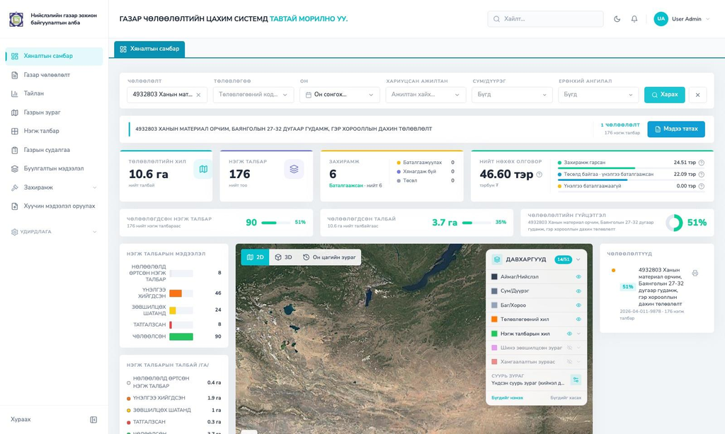

*Зураг 9. Хяналтын самбар*

### 9.1.1 Бүтэн дэлгэцийн хураангуй самбар

**Байрлал:** самбарын газрын зургийн “Дэлгэц дүүргэж харах” товч. Хандах**:** Дотоод хэрэглэгчид

Газрын зургийг бүтэн дэлгэцээр нээхэд зүүн талд сонгосон чөлөөлөлтийн (эсвэл бүх чөлөөлөлтийн) хураангуй самбар гарна. Удирдлагын хурал, танилцуулгад газрын зураг ба гол тоонуудыг нэг дэлгэцээр харуулах зориулалттай.

- **Харагдах мэдээлэл:** нийт нэгж талбар, чөлөөлсөн тоо ба талбай, захирамжийн тоо. Мөн нэгж талбарын явц төлөв тус бүрээр (тоо, хувь, талбай), нөхөх олговрын нийт дүн ба задаргаа (захирамж гарсан, төсөлд байгаа, үнэлгээ баталгаажаагүй), үнэлгээний бүтэц (газар, үл хөдлөх хөрөнгө, эд хөрөнгө), санхүүжилтийн эх үүсвэр, захирамжийн төслийн төлөв, сараар чөлөөлсөн нэгж талбар, газрын судалгааны хураангуй харагдана.
- **Шүүлт ба үйлдэл:** толгой хэсгээс он солих, “Чөлөөлөлтүүд” жагсаалтыг гүйцэтгэлээр нь (бүрэн, хэрэгжиж буй, эхлээгүй) шүүх, нэг чөлөөлөлт рүү орж дэлгэрэнгүйг харах, “←” товчоор буцах, давхаргын самбараас давхарга асааж, унтраах боломжтой.

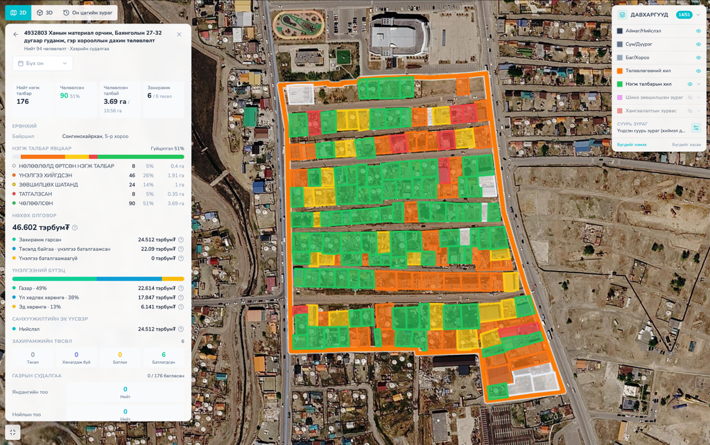

*Зураг 10. Бүтэн дэлгэцийн горим: тухайн чөлөөлөлтийн хураангуй (явц, нөхөх олговор, захирамж, сараар чөлөөлсөн нэгж талбар) ба давхаргын самбар*

### 9.1.2 Он цагийн зураг: явцыг сараар харах

**Байрлал:** газрын зургийн “2D / 3D / Он цагийн зураг” сонголт (хяналтын самбар, чөлөөлөлтийн “Байршил” таб). **Хандах:** дотоод хэрэглэгч

Нэгж талбаруудын явц цаг хугацааны туршид хэрхэн өөрчлөгдснийг сар сараар нь харуулах горим. Нэгж талбар бүр тухайн сарын төлөвийн өнгөөр, изометр (налуу) харагдацаар зурагдана.

- **Цагийн гол:** доод хэсгийн цагийн голоос сар сонгох эсвэл “▶” товчоор сар сараар автоматаар тоглуулах, “Одоогийн байдал” товчоор өнөөдрийн төлөв рүү буцах боломжтой.
- **Самбартай уялдаа:** хяналтын самбар дээр сар сонгоход самбарын бүх тоо (нэгж талбар, талбай, олговор) тухайн сарын байдлаар дахин тооцогдоно.
- **Тайлбар:** төлөв тус бүрийн өнгө ба тоо, эхлээгүй нэгж талбар саарал өнгөөр харагдана.
- **2D газрын зураг сараар:** энгийн газрын зураг дээрх төлөвийн давхарга мөн сонгосон сарын байдлаар зурагдана.

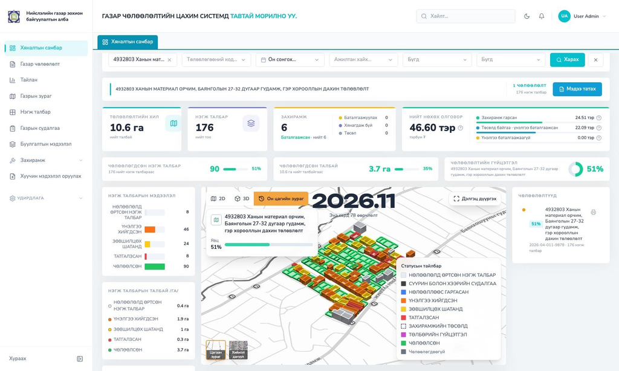

*Зураг 11. Он цагийн зураг: тухайн чөлөөлөлтийн нэгж талбаруудын явц 2026 оны 11-р сарын байдлаар, төлөвийн өнгө ба тайлбартай*

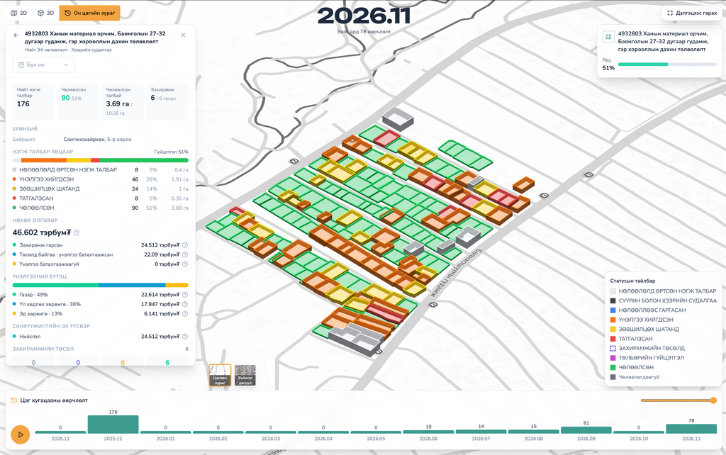

*Зураг 12. Он цагийн зураг, чөлөөлөлтийн “Байршил” табд*

### 9.2 Газар чөлөөлөлтийн жагсаалт

**Зам:** `/acquisition`. **Хандах:** дотоод ажилтан, харин мэргэжлийн байгууллага `/my_acquisitions` руу шилжинэ

**Зорилго.** Бүртгэгдсэн бүх газар чөлөөлөлтийг нэг жагсаалтаар харах, хайх, шинэ чөлөөлөлт бүртгэх. Чөлөөлөлт бүрийн ангилал, төлөв, талбай, нэгж талбарын тоо, гүйцэтгэлийн хувь харагдана.

- **Харагдах мэдээлэл:** Төлөвлөгөө (код + нэр), Чөлөөлөлтийн нэр, Ерөнхий/Дэд ангилал, Статус (Шинэ/Хээрийн судалгаа/Баталгаажсан/Цуцлагдсан), Талбай, Эхлэх огноо, Нэгж талбарын тоо
- **Шүүлтүүрүүд:** Төлөвлөгөө, чөлөөлөлт, ангилал, төлөв, ажилтан, он, мөн “Хайх”, “Цэвэрлэх” товчнууд. Шүүлтүүрийн талбарт Enter дарахад хайна.
- **Эрэмбэлэх:** баганын гарчиг дээр дарж өсөх/буурах дарааллаар эрэмбэлнэ. Эрэмбэ нь бүх хуудсыг хамарч сервер дээр хийгдэнэ. Энэ боломж нэгж талбар, тайлан, захирамж, хэрэглэгч, үйлдлийн лог зэрэг бүх жагсаалтад нэгэн адил ажиллана.
- **Хэлтсийн хамрах хүрээ:** системийн администратороос бусад хэрэглэгч зөвхөн өөрийн хэлтсийн чөлөөлөлтийг харна.
- **Мөрийн үйлдлүүд:** “Дэлгэрэнгүй” линк, “Устгах” (land:delete эрхтэй, баталгаажуулах асуулттай). Баталгаажсан чөлөөлөлт гадаад хэрэглэгчид “Хаалттай” тэмдэгтэй харагдана.

“Нэмэх” товчоор шинэ чөлөөлөлт бүртгэх 2 алхамт цонх нээгдэнэ (зөвхөн ахлах мэргэжилтэн, land:create):

- 1-р алхам: газар зохион байгуулалтын төлөвлөгөөг **нэгж талбарын дугаараар** хайж олох. Систем төлөвлөгөөг олоод хилтэй эсэхийг шалгана
- 2-р алхам: Чөлөөлөлтийн нэр*, Ерөнхий ангилал*, Дэд ангилал*, Эхлэх огноо*, Хэрэгжүүлэгч байгууллага, Хариуцах байгууллага, Чөлөөлөх шалтгаан, эцэст нь “Бүртгэх” товч.

**Хилийн эх сурвалж өөрчлөгдсөн:** чөлөөлөлтийн хилийг гараар shapefile (.shp zip) байршуулдаг байсныг больж, **төлөвлөгөөний хилээс автоматаар хуулдаг** болсон. Хилгүй төлөвлөгөөгөөр үргэлжлүүлэх боломжгүй бөгөөд систем “Төлөвлөгөөнд хил бүртгэгдээгүй тул чөлөөлөлт үүсгэх боломжгүй” гэж зогсооно (backend мөн 422 буцаана). Мөн санхүүжилтийн эх үүсвэрийг энэ цонхонд бүртгэхээ больж, “Санхүүжилт” таб болон захирамжийн төсөлд шилжүүлсэн. Чөлөөлөлтийн нэрийн өмнө төлөвлөгөөний дугаар автоматаар залгагдана, жишээ нь `(12346) Нэр`.

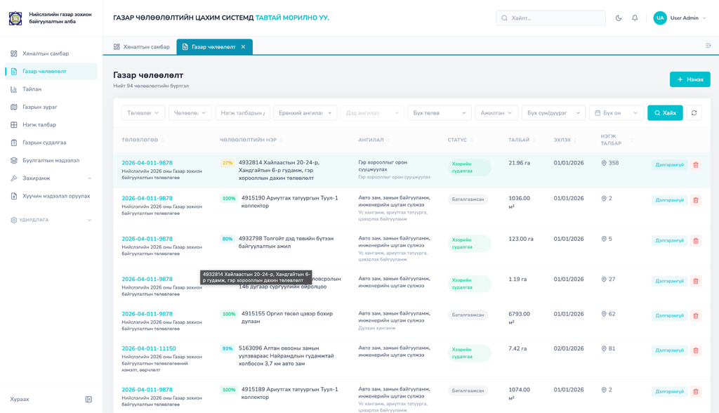

*Зураг 13. Газар чөлөөлөлтийн жагсаалт: шүүлтүүрүүд, явцын хувь, статусын тэмдэглэгээ, мөрийн үйлдлүүд*

### 9.3 Газар чөлөөлөлтийн дэлгэрэнгүй (8 таб)

**Зам:** `/acquisition/[id]`

**Зорилго.** Нэг чөлөөлөлтийн бүх мэдээлэл болох үндсэн мэдээлэл, баримт, нэгж талбар, санхүүжилт, явц, хариуцсан ажилтан, байршил, газрын судалгааг табуудаар ангилан удирдах.

Толгой хэсэгт нэр, статус, төлөвлөгөөний код, “Тайлан татах” (тухайн чөлөөлөлтийн Excel тайлан) товч байрлана. Баталгаажсан чөлөөлөлт бүх засварыг түгжинэ. Гадаад ролиуд зөвхөн “Ерөнхий мэдээлэл” ба “Нэгж талбарууд” табыг харна.

Дэлгэрэнгүй хуудас нь найман табтай. Таб бүрийн зориулалт, харагдах мэдээлэл, үйлдлийг доор зурагтай нь тайлбарлав.

#### “Ерөнхий мэдээлэл” таб

**Зориулалт.** Чөлөөлөлтийн үндсэн болон төслийн мэдээллийг нэг дор харах, засах.

- **Харагдах мэдээлэл:** төлөвлөгөөний дугаар, чөлөөлөлтийн нэр, ерөнхий ба дэд ангилал, талбай, эхлэх, дуусах огноо, байршил. Төслийн мэдээлэлд хэрэгжүүлэгч ба хариуцах байгууллага, мэргэжлийн байгууллага, НИТХ-ын тогтоолын дугаар, бүлэг жагсаалтын дугаар, НЗД-ын захирамжийн дугаар, огноо, чөлөөлөх шалтгаан багтана. Доод хэсэгт нийгэм, эдийн засгийн судалгааны дүн (9.3.1) харагдана.
- **Үйлдлүүд:** “Засах” товчоор мэдээллийг засах, мэргэжлийн байгууллага сонгох, талбайг “Хилээс тооцоолох” боломжтой. Мөн **хил солих** боломжтой бөгөөд төлөвлөгөөний дугаараар эсвэл .shp файлаар шинэ хил оруулахад шинэ хилээс гадна үлдэх нэгж талбаруудыг дугаар, төлөвтэй нь урьдчилан жагсааж, хэрэглэгч зөвшөөрсний дараа л хил солигдоно (хилээс гарсан нэгж талбар автоматаар устахгүй). Түүнчлэн “Устгах” үйлдэлтэй бөгөөд толгой хэсгийн “Тайлан татах” товчоор тухайн чөлөөлөлтийн Excel тайланг татна.
- **Эрх:** засах, устгах үйлдэл ахлах мэргэжилтэн ба администраторт олгогдоно. Баталгаажсан чөлөөлөлтийн мэдээлэл түгжигдэнэ.

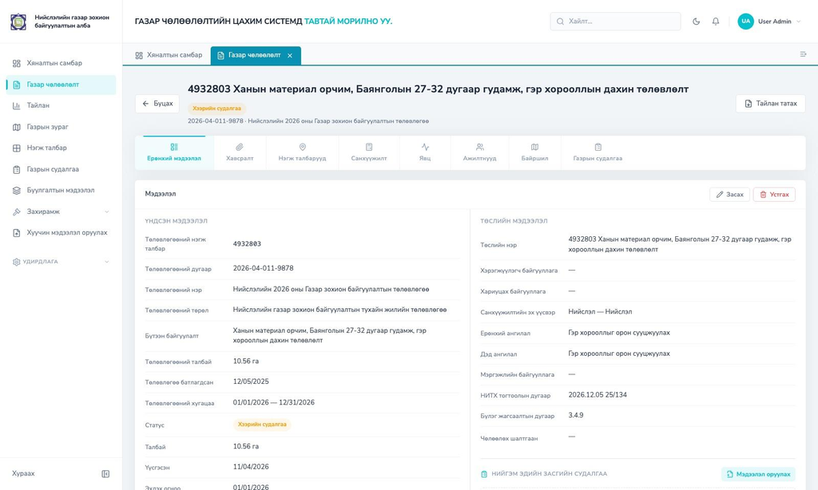

*Зураг 14. “Ерөнхий мэдээлэл” таб: үндсэн ба төслийн мэдээлэл*

#### “Хавсралт” таб

**Зориулалт.** Чөлөөлөлтийн түвшний албан баримт бичгийг (төлөвлөгөө, тогтоол, хурлын тэмдэглэл, зураг төсөл г.м.) нэг дор хадгалах.

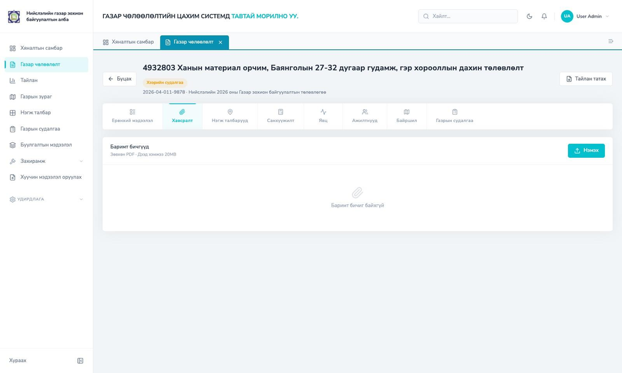

*Зураг 15. “Хавсралт” таб: чөлөөлөлтийн баримт бичиг*

#### “Нэгж талбарууд” таб

**Зориулалт.** Чөлөөлөлтөд өртсөн нэгж талбаруудыг жагсааж, тус бүрийн явц, нөхөх олговрыг хянах.

- **Харагдах мэдээлэл:** нэгж талбарын дугаар, эзэмшигч, хаяг, эрхийн төрөл, зориулалт, нийт ба чөлөөлөгдөх талбай, давхцал, нөхөх олговрын дүн ба олголтын шат, төлөв
- **Шүүлтүүр:** дугаар, эзэмшигч, захиргааны нэгж, эрхийн төрөл, зориулалт, төлөв, давхцал. Мөн баганаар эрэмбэлэх боломжтой.
- **Үйлдлүүд:** “Нэгж талбар татах” үйлдлээр чөлөөлөх хилтэй огтлолцох нэгж талбаруудыг кадастрын системээс тодорхойлж бүртгэнэ. Мөр дээр дарж нэгж талбарын дэлгэрэнгүй рүү шилжинэ.
- **Эрх:** Санхүүгийн мэргэжилтэн зөвхөн үнэлгээ нь илгээгдсэн нэгж талбаруудыг харна.

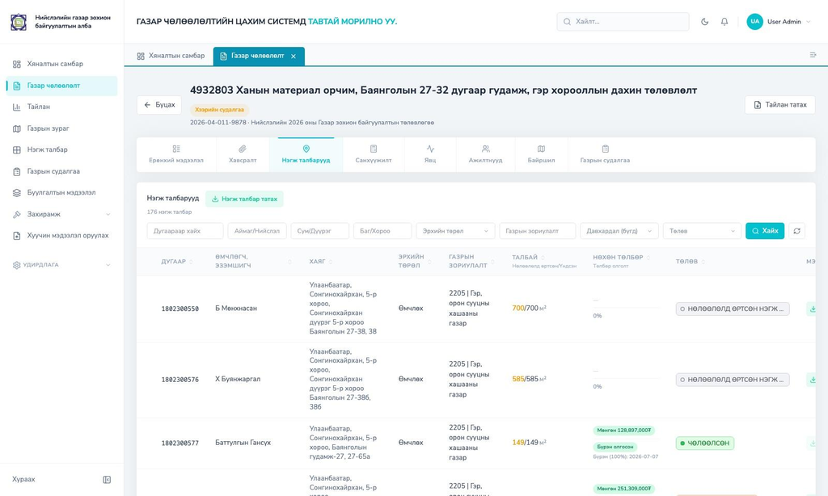

*Зураг 16. “Нэгж талбарууд” таб: нэгж талбарын жагсаалт, шүүлтүүр, төлөв*

**“Нэгж талбар татах” хэрхэн ажилладаг вэ:** Товч дарахад чөлөөлөх хилтэй огтлолцох нэгж талбаруудыг кадастрын системээс тодорхойлж бүртгэх бөгөөд дуусахад “N нэгж талбар шинээр бүртгэгдлээ” гэж мэдэгдэнэ. Нэгж талбар бүрийн дэлгэрэнгүй мэдээлэл (эзэмшигч, төлбөр, барьцаа, мониторинг г.м.) нь нэгж талбарын “Мэдээлэл дуудах” товчоор, эсвэл “Нэгж талбар” жагсаалтаас олон нэгж талбарыг сонгон нэг дор татагдана.

#### “Санхүүжилт” таб

**Зориулалт.** Чөлөөлөлтийн санхүүжилтийн эх үүсвэрүүдийг бүртгэж, нөхөх олговрын зарцуулалтыг хянах.

- **Харагдах мэдээлэл:** Эх үүсвэр тус бүрийн байгууллага, төрөл, дүн, валют, тайлбар, нийт дүн харагдана. Баруун талд нэгж талбарын тоо, батлагдсан, ашигласан, үлдэгдэл дүн, төлөвөөр задалсан график, үнэлгээний бүтэц (газар, үл хөдлөх, эд хөрөнгө) байрлана.
- **Үйлдлүүд:** “Нэмэх”, “Засах”, “Устгах”
- **Эрх:** Бүртгэх, засах нь ахлах мэргэжилтэнд хамаарна.

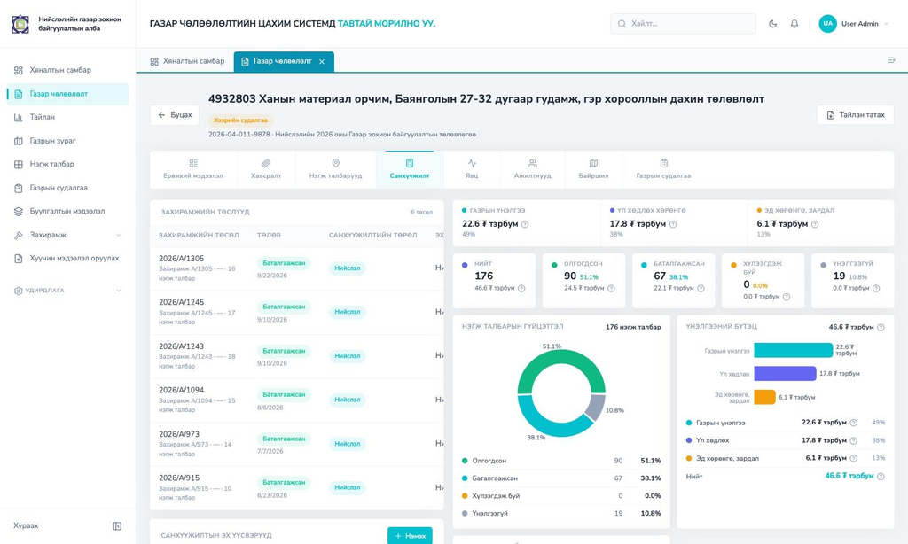

*Зураг 17. “Санхүүжилт” таб: эх үүсвэр, батлагдсан ба ашигласан дүн, график*

#### “Явц” таб

**Зориулалт.** Чөлөөлөлтийн төлөвийг “Шинэ”, “Хээрийн судалгаа”, “Баталгаажсан” гэсэн дарааллаар (мөн “Цуцлагдсан”) шилжүүлэх, түүхийг харах.

- **Харагдах мэдээлэл:** Одоогийн төлөв болон явцын түүх (төлөв, тайлбар, өөрчилсөн хэрэглэгч, огноо).
- **Үйлдлүүд:** “Явц солих” дарж тохиргоогоор зөвшөөрөгдсөн дараагийн төлөвийг сонгоно. “Хээрийн судалгаа” руу шилжихэд нэгж талбарууд бүрдсэн, давхцалгүй байх, “Баталгаажсан” руу шилжихэд НЗД-ын захирамжийн дугаар, огноо бөглөгдсөн, бүх нэгж талбар эцсийн төлөвт байх шаардлагатай.
- **Эрх:** Ахлах мэргэжилтэн ба администратор. “Баталгаажсан” чөлөөлөлтийн бүх засвар түгжигдэнэ.

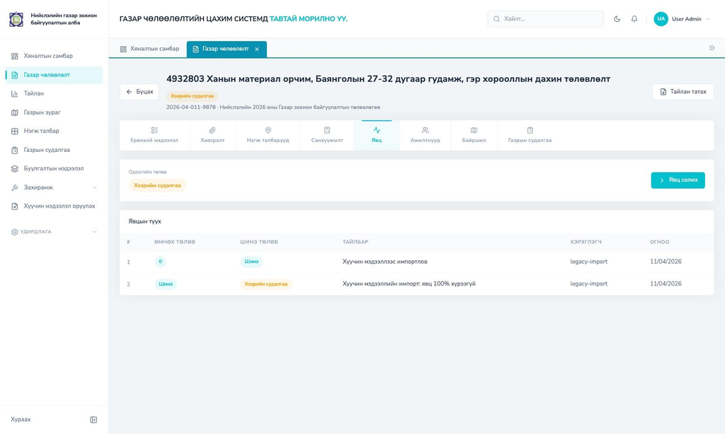

*Зураг 18. “Явц” таб: одоогийн төлөв ба явцын түүх*

#### “Ажилтнууд” таб

**Зориулалт.** Чөлөөлөлтийг хариуцан ажиллах ажилтнуудыг хуваарилах.

- **Харагдах мэдээлэл:** Ажилтны нэр, албан тушаал, хэлтэс, хуваарилсан огноо.
- **Үйлдлүүд:** “Ажилтан нэмэх” дарж нэр, албан тушаалаар хайж олон ажилтныг сонгоод баталгаажуулна. Ажилтныг хасаж болно. Шинээр нэмэгдсэн ажилтанд мэдэгдэл очно.
- **Эрх:** Хуваарилах нь ахлах мэргэжилтэнд хамаарна. Зөвхөн хуваарилагдсан ажилтан тухайн чөлөөлөлтийн нэгж талбарын мэдээллийг засна.

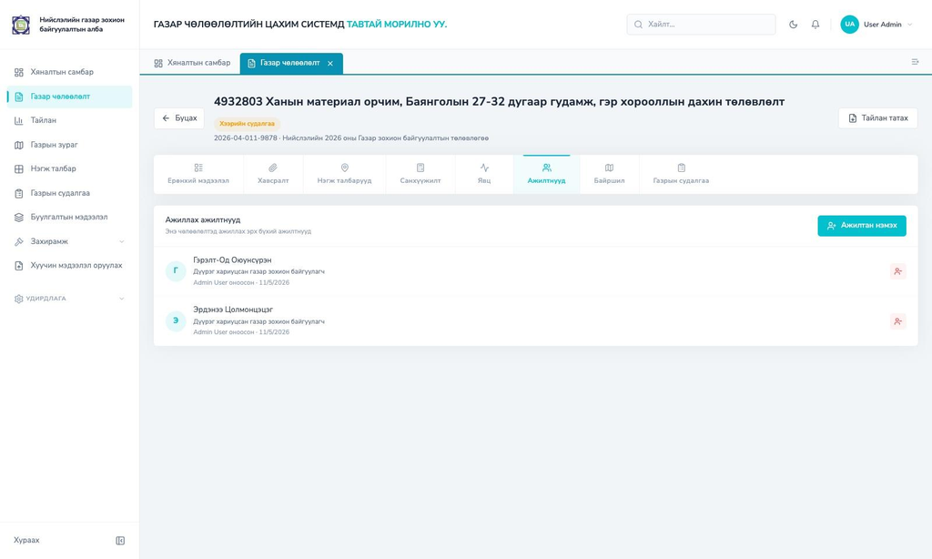

*Зураг 19. “Ажилтнууд” таб: хуваарилагдсан ажилтнууд*

#### “Байршил” таб

**Зориулалт.** Чөлөөлөлтийн хил, нэгж талбаруудыг газрын зураг дээр харах, хэвлэх.

- **Харагдах мэдээлэл:** Чөлөөлөлтийн ба төлөвлөгөөний хил, төлөвийн өнгөөр ялгасан нэгж талбарууд, захиргааны нэгж, ГУС-ийн давхаргууд, дроны ортофотогийн жагсаалт, байршил (дүүрэг, хороо).
- **Үйлдлүүд:** Давхарга асаах, унтраах (9.9.1), “2D”, “3D”, “Он цагийн зураг” горим (9.1.2), бүтэн дэлгэц, “Ажлын зураг” хэвлэх (9.9.2). Мөн дроны зураг (.tif) оруулах, GeoServer-т шинэчлэх, зураг дээр очих, асаах, унтраах, устгах.

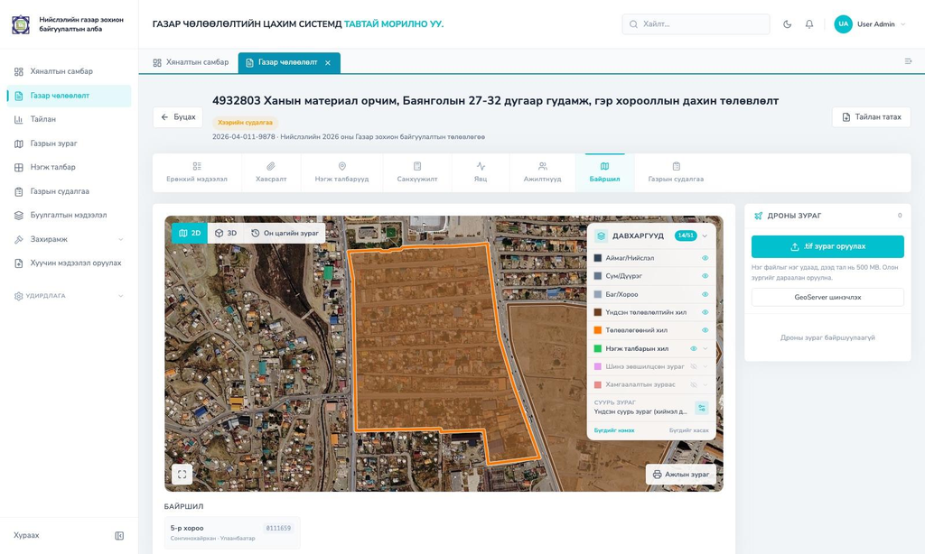

*Зураг 20. “Байршил” таб: хил, нэгж талбар, давхаргын самбар, дроны зураг*

#### “Газрын судалгаа” таб

**Зориулалт.** Тухайн чөлөөлөлтийн хүрээний газрын судалгааг нэгтгэн харах.

- **Харагдах мэдээлэл:** Хураангуйд яндангийн тоо, нойлын тоо, хажуу өрхийн судалгаа, шилжин суурьшсан байршил (гэр хороолол, орон сууц) харагдана. Мөн нэгж талбар тус бүрийн судалгаа ба бөглөсөн эсэх харагдана.
- **Шүүлтүүр:** Нэгж талбарын дугаар, бөглөсөн эсэх.
- **Үйлдлүүд:** Мөр бүрийн “Бөглөх” товчоор нэгж талбарын “Судалгаа” таб нээгдэнэ (9.17).

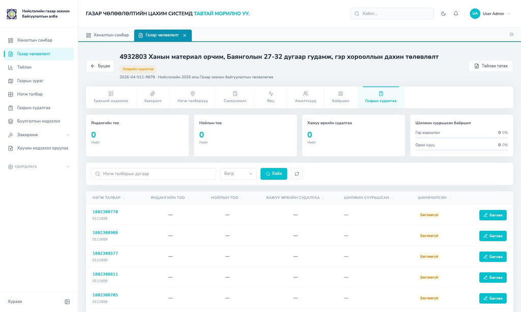

*Зураг 21. “Газрын судалгаа” таб: судалгааны хураангуй ба нэгж талбарын жагсаалт*

### 9.3.1 Нийгэм, эдийн засгийн судалгаа (2.4.2.1)

**Байрлал:** “Ерөнхий мэдээлэл” табын “Төслийн мэдээлэл”-ийн доод хэсэг. **Эрх:** `land:read` харах, `land:update` бүртгэх.

Чөлөөлөлтөд өртсөн иргэд, хуулийн этгээдийн дунд хийсэн нийгэм, эдийн засгийн судалгааны дүнг чөлөөлөлт бүрт нэг удаа бүртгэнэ. “Мэдээлэл оруулах” товч дарахад маягт нээгдэнэ.

- **Бөглөх талбарууд:** **Зөвшөөрсөн** (тоогоор)*, **Татгалзсан** (тоогоор)*, **Тайлбар**. Тоо нь сөрөг байж болохгүй (сангийн түвшинд CHECK).
- **Судалгааны файл заавал** хавсаргах бөгөөд зөвхөн **PDF** хүлээн авна. Олон файл сонговол хөтөч дотор (pdf-lib) **нэг PDF болгож нэгтгээд** хадгална.
- **Дахин хадгалах:** Шинэ файл сонгоогүй бол өмнөх файл хэвээр үлдэнэ. Шинэ файл орвол хуучин объект файлын сангаас устгагдана (хог үлдэхгүй).
- **Хадгалалт:** Мэдээлэл `acquisition_socio_survey` (чөлөөлөлт тус бүрт UNIQUE) хүснэгтэд, файл нь MinIO-гийн `socio-survey/` хэсэгт хадгалагдана. Татахад файлын хандалтын шалгалт (6-р бүлэг) хэрэгжинэ.

### 9.4 Нэгж талбарын нэгдсэн жагсаалт

**Зам:** `/parcel`. **Хандах:** дотоод ажилтан.

**Зорилго.** Бүх чөлөөлөлтийн нэгж талбарыг нэг жагсаалтаар харах, хайх, олон нэгж талбарын мэдээллийг ГУС-ээс нэг дор татах.

- **Харагдах мэдээлэл:** Дугаар, Чөлөөлөлт (нэр + төлөвлөгөөний код), Огноо, Чөлөөлөлтийн төлөв, Эрхийн төрөл, Зориулалт, Талбай, Нөхөн төлбөрийн хэлбэр, Төлөв.
- **Шүүлт ба үйлдэл:** Талбарын дугаар, төлөвлөгөө, чөлөөлөлт, эрхийн төрөл, зориулалт, төлөв, **оноор** (нэгж талбарын төлөв хамгийн сүүлд өөрчлөгдсөн огноогоор) шүүнэ. Баганаар эрэмбэлнэ. “Дэлгэрэнгүй” линк талбарын хуудас руу очно.
- **Олон нэгж талбарын мэдээлэл дуудах:** Жагсаалтаас нэгж талбаруудыг сонгож ГУС-ийн мэдээллийг нэг дор татна. Алхам бүрийн явц тусдаа цонхонд харагдана.
- **Олголтын тэмдэг:** Нөхөх олговор олгосон шат (60%, 40%, бүтэн) мөр бүр дээр тэмдгээр харагдана.

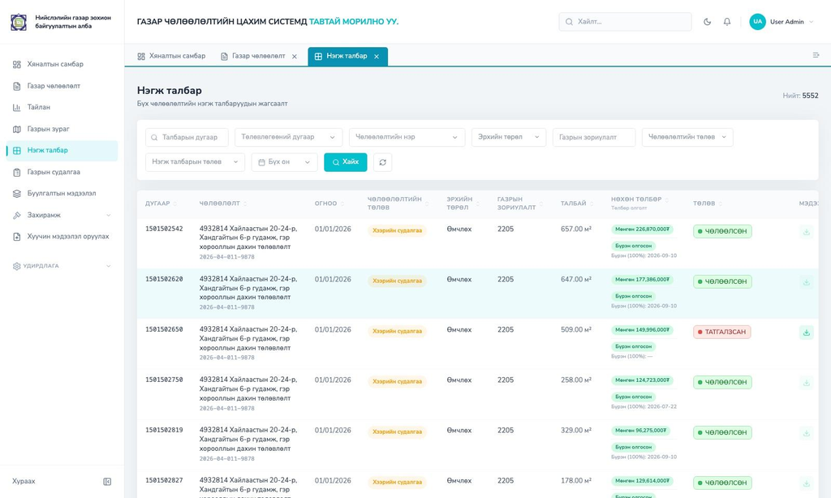

*Зураг 22. Нэгж талбарын нэгдсэн жагсаалт: шүүлтүүр, төлөв, олговрын тэмдэг*

### 9.5 Нэгж талбарын дэлгэрэнгүй (9 таб)

**Зам:** `/parcel/[id]?acq=[acqId]`. **Хандах:** дотоод ажилтан, гадаад рольд таб хязгаарлагдана.

**Зорилго.** Нэг нэгж талбарын кадастрын мэдээлэл, эзэмшигч, төлбөр, үнэлгээ, нөхөх олговор, баримт, захирамж, хэвлэх загвар, явц, судалгааг табуудаар ангилан удирдах.

Талбар “Чөлөөлсөн”, “Татгалзсан”, “Нөлөөллөөс гаргасан” төлөвт орсон эсвэл чөлөөлөлт баталгаажсан үед засвар түгжигдэнэ. Мэргэжлийн байгууллага бүх үйлдлээ /prof порталаар хийнэ. Табын тоо эрхээс хамаарч өөрчлөгдөнө: дотоод ажилтанд 9, мэргэжлийн байгууллагад “Ерөнхий мэдээлэл”, “Эзэмшигч”, “Нөхөх олговор” гэсэн гурав, МИКА болон санхүүд “Ерөнхий мэдээлэл”, “Нөхөх олговор” гэсэн хоёр таб харагдана. “Захирамж” таб нь `decision:read` эрхтэй хэрэглэгчид л харагдана.

Дэлгэрэнгүй хуудас нь есөн табтай. Таб бүрийн зориулалт, харагдах мэдээлэл, үйлдлийг доор зурагтай нь тайлбарлав.

#### “Ерөнхий мэдээлэл” таб

**Зориулалт.** Нэгж талбарын кадастрын болон чөлөөлөлтийн үндсэн мэдээлэл, байршлыг харах.

- **Харагдах мэдээлэл:** Дугаар, захиргааны нэгж, хаяг, эрхийн төрөл, зориулалт, нийт, чөлөөлөгдөх ба үлдэх талбай, төсөөллийн үнэлгээ. Байршлын зурагт нэгж талбарын хил, хөрш нэгж талбарууд харагдана. Өөр нэгж талбартай давхцаж байвал улаан анхааруулга, давхцлын талбай гарна.
- **Үйлдлүүд:** “Засах” үйлдлээр чөлөөлөгдөх талбай, хил, мэдээллийн санд өөрчлөлт орсон тэмдэглэгээг засна. Мөн “Хилээс тооцоолох”, “Мэдээлэл дуудах” (ГУС-ийн кадастр, төлбөр, үнэлгээ, мониторинг, УБЕГ-ийн өмчлөлийн мэдээллийг алхам алхмаар татна), “Үнэлгээ оруулах” (9.5.5), “Трас зураг” (9.5.6) үйлдлүүд байна.
- **Эрх:** Давхцлыг арилгах хүртэл нэгж талбарыг дараагийн шат руу шилжүүлэхгүй. Эцсийн төлөвт орсон нэгж талбарын мэдээлэл түгжигдэнэ.

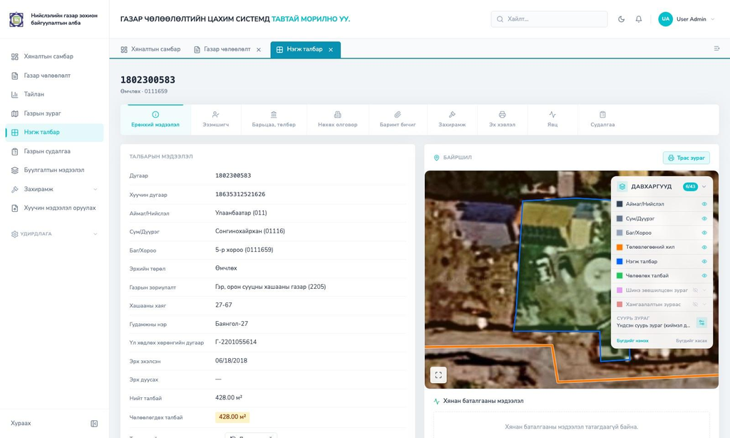

*Зураг 23. “Ерөнхий мэдээлэл” таб: нэгж талбарын мэдээлэл ба байршил*

#### “Эзэмшигч” таб

**Зориулалт.** Газар эзэмшигч, өмчлөгч, итгэмжлэгдсэн төлөөлөгчийн мэдээллийг харах, мэдэгдэл хүргүүлэх.

- **Харагдах мэдээлэл:** Эзэмшигчийн нэр, регистр, холбоо барих мэдээлэл, өргөдөл, шийдвэр, гэрээ, гэрчилгээний дугаар, огноо. Мөн УБЕГ-ийн газар өмчлөлийн бүртгэл (9.5.3), газрын үнэлгээ (бүс, суурь үнэ, итгэлцүүр), итгэмжлэгдсэн төлөөлөгч харагдана.
- **Үйлдлүүд:** Итгэмжлэгдсэн төлөөлөгч бүртгэх, устгах, “Нөхөн төлбөр авагч” сонгох, УБЕГ-ийн мэдээллийг “Шинэчлэх”, “Мэдэгдэх хуудас илгээх” (9.5.4).
- **Эрх:** Мэдэгдэх хуудас илгээх нь системийн администраторт хамаарна.

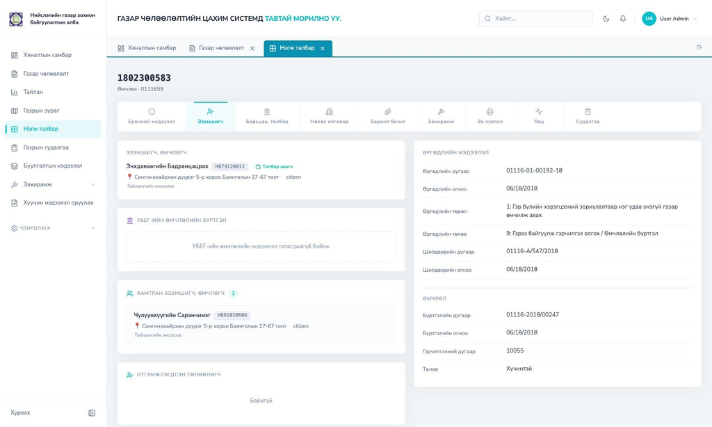

*Зураг 24. “Эзэмшигч” таб: эзэмшигч, өмчлөгч, газрын үнэлгээ*

#### “Барьцаа, төлбөр” таб

**Зориулалт.** Нөхөх олговор олгохын өмнө нэгж талбартай холбоотой эрсдэлийг шалгах.

- **Харагдах мэдээлэл:** Газрын төлбөрийн нэхэмжлэл (нийт, төлсөн, үлдэгдэл), газрын төлбөрийн бодолт, газрын суурь үнэ, барьцааны мэдээлэл ба гэрээний хавсралт, шүүхийн шийдвэрийн мэдээлэл.
- **Үйлдлүүд:** Мэдээлэл ГУС-ээс “Мэдээлэл дуудах” үйлдлээр шинэчлэгдэнэ. Татвар, төлбөр төлөгдөхөд ГУС дээр шинэчлэгдсэн мэдээлэл дахин татагдана.
- **Эрх:** Зөвхөн дотоод ажилтан.

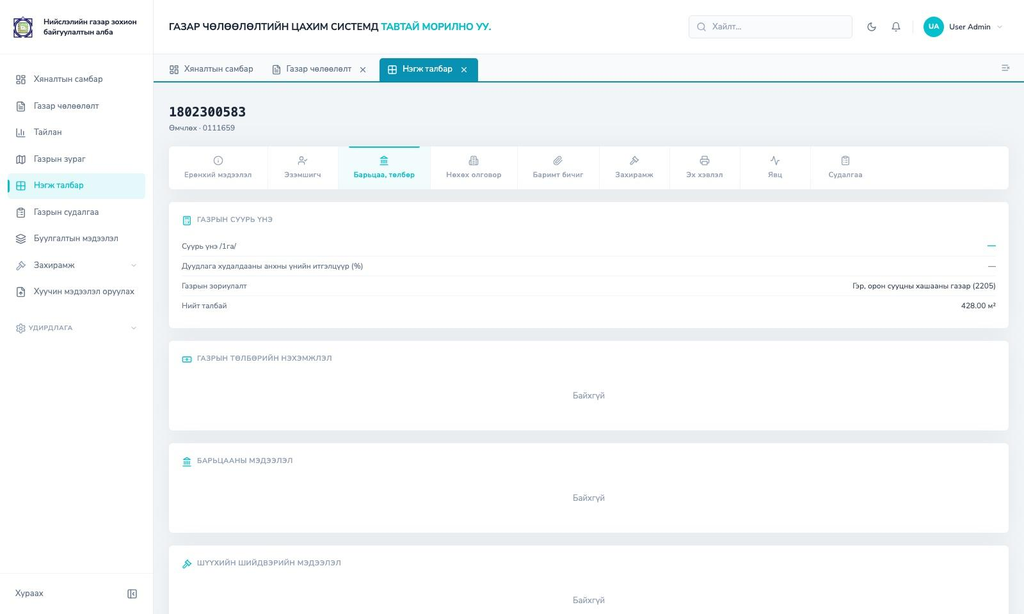

*Зураг 25. “Барьцаа, төлбөр” таб: төлбөр, барьцаа, шүүхийн шийдвэр*

#### “Нөхөх олговор” таб

**Зориулалт.** Нэгж талбарын хөрөнгийн үнэлгээ, нөхөх олговрын тооцоо, баталгаажуулалтыг хийх.

- **Харагдах мэдээлэл:** Үндсэн, хөндлөнгийн, МИКА үнэлгээний гурван дэд таб, урсгал тус бүрийн төлөв. Мөн газрын үнэлгээ, үл хөдлөх хөрөнгө, эд хөрөнгө, нийт дүнгийн нэгтгэл, хөрөнгийн жагсаалт ба тооцоо.
- **Үйлдлүүд:** Үнэлгээ оруулах, Excel-ээс оруулах, илгээх, баталгаажуулах, буцаах. Дэлгэрэнгүйг 9.5.1-ээс үзнэ үү.

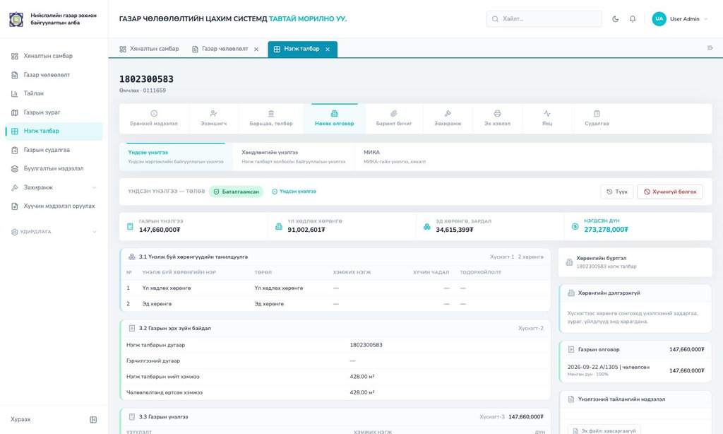

*Зураг 26. “Нөхөх олговор” таб: үнэлгээний урсгалууд ба нэгтгэл*

#### “Баримт бичиг” таб

**Зориулалт.** Нэгж талбарын албан баримт бичгийг хадгалах.

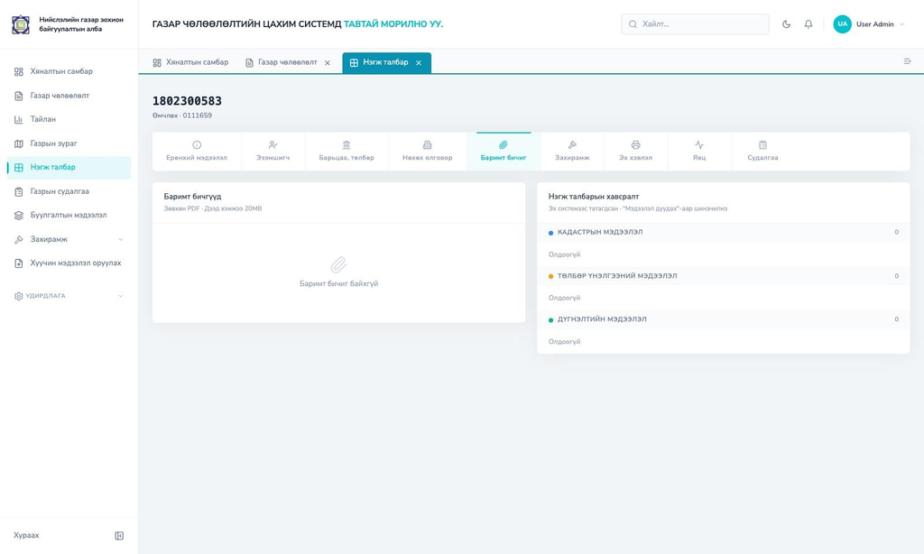

*Зураг 27. “Баримт бичиг” таб: хавсралтууд*

#### “Захирамж” таб

**Зориулалт.** Тухайн нэгж талбартай холбогдсон захирамжийн төсөл, шийдвэрийг харах.

- **Харагдах мэдээлэл:** Саналын хуудасны дугаар, захирамжийн дугаар, огноо, байршил, он, ажлын төрөл, төлөв, хянагдаж буй газар, шинэчилсэн огноо.
- **Эрх:** `decision:read` зөвшөөрөлтэй хэрэглэгчид харагдана.

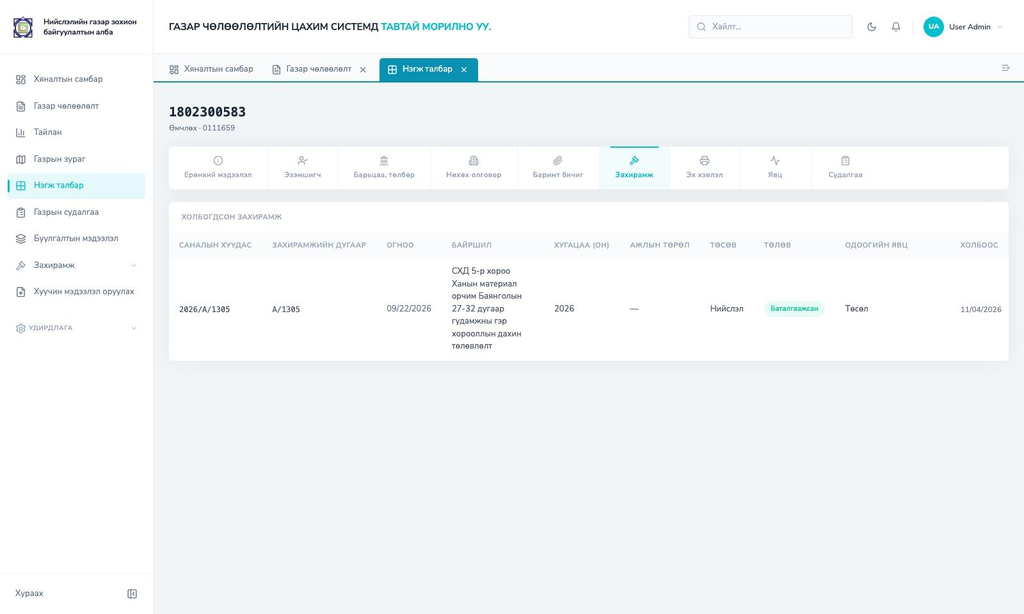

*Зураг 28. “Захирамж” таб: холбогдсон захирамжууд*

#### “Эх хэвлэл” таб

**Зориулалт.** Нэгж талбарын мэдээллээр автоматаар бөглөгдөх албан баримтыг үүсгэх.

- **Харагдах мэдээлэл:** 19 загварын жагсаалт ба тайлбар (9.5.2).
- **Үйлдлүүд:** “Татах” дарахад загвар нэгж талбар, эзэмшигч, чөлөөлөлт, ажилтны мэдээллээр бөглөгдөж Word эсвэл Excel файл болж татагдана.

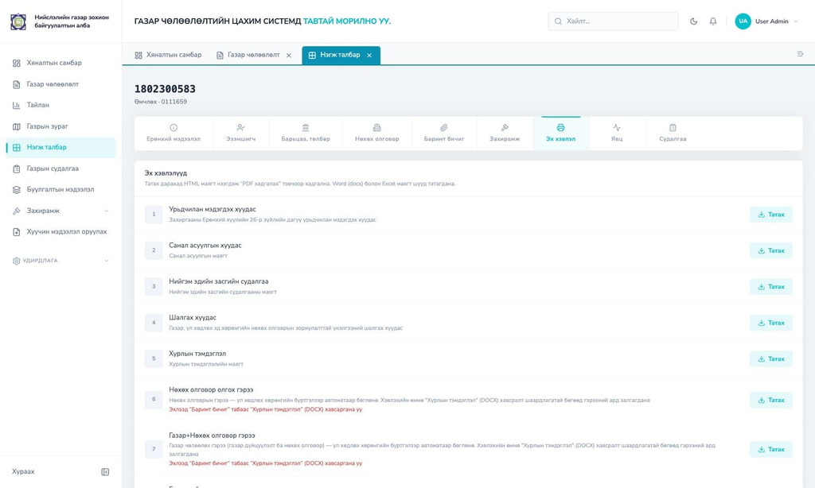

*Зураг 29. “Эх хэвлэл” таб: албан баримтын загварууд*

#### “Явц” таб

**Зориулалт.** Нэгж талбарын төлөвийг шилжүүлэх, түүхийг харах.

- **Харагдах мэдээлэл:** Одоогийн төлөв, тухайн төлөвт байгаа хугацаа, мөн явцын түүх (төлөв, тайлбар, хэрэглэгч, огноо, хавсралт).
- **Үйлдлүүд:** “Явц нэмэх” дарж тохиргоогоор зөвшөөрөгдсөн дараагийн төлөвийг сонгоод, тайлбар болон шаардлагатай хавсралтыг оруулна. Систем шилжилт бүрт заавал хавсралт, нөхөх олговрын баталгаажуулалт зэрэг нөхцөлийг шалгана (9.15.3).

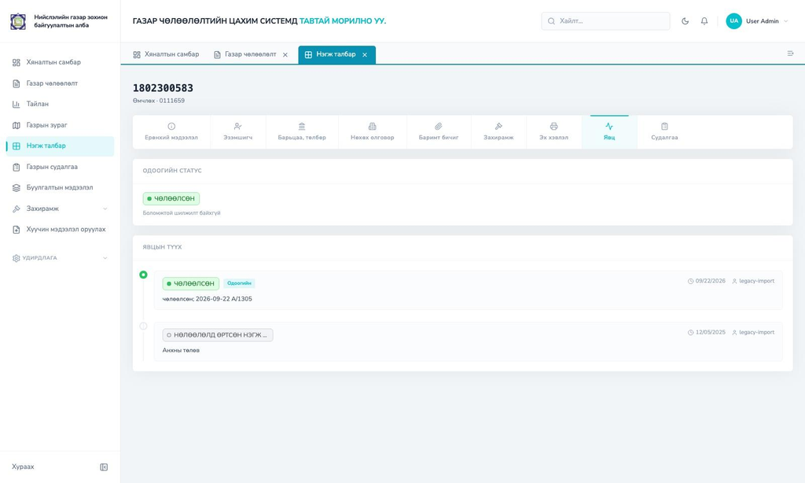

*Зураг 30. “Явц” таб: одоогийн төлөв ба явцын түүх*

#### “Судалгаа” таб

**Зориулалт.** Чөлөөлөгдсөн газрын нөхцөл байдлыг бүртгэх.

- **Харагдах мэдээлэл ба үйлдлүүд:** Яндангийн тоо, нойлын тоо, хажуу өрхийн судалгааг “+”, “−” товчоор оруулж, шилжин суурьшсан байршлыг (“Гэр хороолол”, “Орон сууц”) сонгоод, тайлбар бичиж “Хадгалах” товч дарна (9.17).

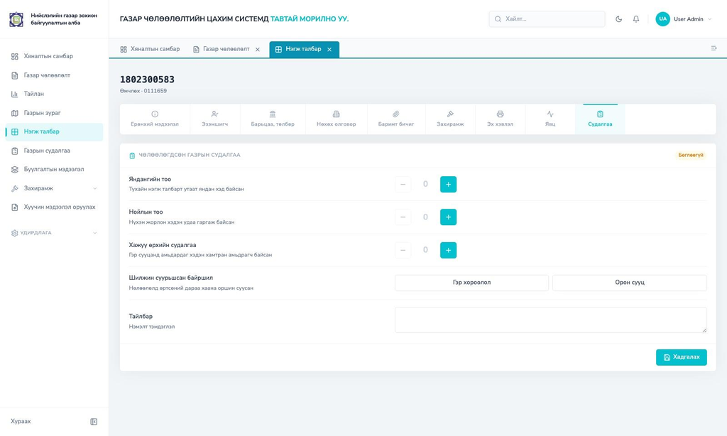

*Зураг 31. “Судалгаа” таб: газрын судалгааны маягт*

### 9.5.1 “Нөхөх олговор” табын үнэлгээний 3 дэд таб

**Гол урсгал:** Илгээх, дараа нь Баталгаажуулах эсвэл Буцаах.

“Үндсэн үнэлгээ” (мэргэжлийн байгууллага), “Хөндлөнгийн үнэлгээ” (хөндлөнгийн байгууллага), “МИКА” гэсэн 3 зэрэгцээ урсгал. Санхүүгийн баталсан урсгал “Үндсэн үнэлгээ” болж, бусад нь “Идэвхгүй” тэмдэглэгддэг.

- **Илгээх-батлах workflow:** Төлөвийн зурваст “Ноорог”, “Илгээсэн”, дараа нь “Баталгаажсан”, “Буцаагдсан” эсвэл “Татгалзсан” гэсэн дарааллаар төлөв харагдана. “Түүх” товч бүх шилжилтийг харуулна.
- **Шилжилтийн товчнууд:** “Илгээх” (үнэлгээ оруулсан байгууллага), “Буцаах” ба “Нөхөх олговор баталгаажуулах” (санхүүгийн мэргэжилтэн). Бүгд тайлбар* шаардана.
- **Excel импорт:** “Excel-ээс оруулах” үйлдлээр .xlsx файлыг хөтөч дотор задалж, үнэлгээний байгууллага, газрын үнэлгээ, хөрөнгийн тодорхойлол, өртгийн хандлага, зардлын хэсгүүдийг урьдчилан харуулна. Засварласны дараа “Системд оруулах” дарна. Давхардлыг SHA-256 хэшээр шалгана.
- **Байгууламж:** “Хөрөнгө нэмэх” үйлдлээр байгууламжийн дугаар, төрөл (үл хөдлөх/эд хөрөнгө), нэр, давхар, талбай, эзэмшигчийг бүртгэнэ. Мөн чанарын үзүүлэлт ба тооцооллын утгууд, олговрын мөрүүд (хэлбэр, хувь, дүн) оруулж, зураг хавсаргана (PDF болно).
- **Олговрын хяналт:** Хүснэгтийн өргөтгөх мөрөнд олговрын задаргаа харагдана. Санхүү pending олговор дээр “Зөвшөөрөх” эсвэл “Татгалзах” (тайлбартай) үйлдэл хийнэ. Мөн олговрын түүхийг харна.
- **Газрын үнэлгээ:** Талбай × м²-ийн суурь үнэ = нийт дүн. “Хадгалах”, “Устгах” товчтой.
- **Тайлан ба байгууллага:** “Тайлан хавсаргах/солих” үйлдлээр сонгогдсон урсгал дээр үнэлгээний тайланг талбарын баримтаар хадгална. Мөн “Хөндлөнгийн байгууллага холбох/солих/салгах” үйлдэлтэй.
- **Нэгтгэл:** Газрын үнэлгээ, хөрөнгийн үнэлгээ, нэгдсэн дүнгийн нэгтгэл картууд.
- **Нэг хуудастай Excel:** Үнэлгээний шинэ загварын нэг хуудастай Excel файлыг мөн уншиж оруулна. Хүснэгт бүрийн доор тайлбар харагдана.
- **Барилгын тодорхойлолт, өртөг засах:** Барилгын тодорхойлолт, өртгийн тооцооллыг тусдаа цонхонд засна.
- **Илгээсэн хувилбар, хүчингүй болгох:** Илгээх бүрт үнэлгээний хувилбар хадгалагдаж, түүхээс өмнөх хувилбарыг харна. Буцаахдаа баримт хавсаргана. Баталгаажсан үнэлгээг санхүүгийн мэргэжилтэн тайлбартайгаар хүчингүй болгоно.

### 9.5.2 “Эх хэвлэл” хэсгийн хэвлэх загварууд (19)

Бүх загвар системийн мэдээллээр автоматаар бөглөгдөнө. 2026-09-09-өөс хойш 7 загвар нэмэгдсэн.

[output not shown]